# Сегментация и анализ поведения пользователей мобильного приложения

# Содержание

Краткое описание проекта: отделу развития продукта мобильного приложения "Ненужные вещи", в котором пользователи продают свои ненужные вещи, размещая их на доске объявлений, необходимо увеличить монетизацию продукта путем выделения ключевых с точки зрения конверсии и удержания сегментов пользователей, на которые планируется ориентироваться при прогнозировании дальнейшего развития продукта.

Описание данных:

Структура `mobile_dataset.csv`:

- `event.time` — время совершения,
- `user.id` — идентификатор пользователя,
- `event.name` — действие пользователя.  
  Виды действий:
  - `advert_open` — открыл карточки объявления,
  - `photos_show` — просмотрел фотографии в объявлении,
  - `tips_show` — увидел рекомендованные объявления,
  - `tips_click` — кликнул по рекомендованному объявлению,
  - `contacts_show` и `show_contacts` — посмотрел номер телефона,
  - `contacts_call` — позвонил по номеру из объявления,
  - `map` — открыл карту объявлений,
  - `search_1` — `search_7` — разные действия, связанные с поиском по сайту,
  - `favorites_add` — добавил объявление в избранное.

Структура `mobile_sources.csv`:

- `userId` — идентификатор пользователя,
- `source` — источник, с которого пользователь установил приложение.

План работы:

1. Выгрузка данных и первичное знакомство.
2. Предобработка данных.
3. Исследовательский анализ данных.
   - Расчет коэффициента удержания;
   - Анализ продолжительности сессии;
   - Анализ частоты действий;
   - Расчет конверсии в просмотры контактов.
4. Сегментация пользователей и выбор приоритетных сегментов.
   - Сегментация пользователей по частоте действий;
   - Характеристика сегментов по коэффициенту удержания;
   - Характеристика сегментов по конверсии в просмотры контактов.
5. Проверка статистических гипотез по источнику установки приложения.
   - Выбор уровня значимости и поправка на множественность;
   - Сравнение коэффициентов удержания;
   - Сравнение конверсий в просмотры контактов;
   - Сравнение средней продолжительности сессии;
   - Сравнение средней частоты действий.
6. Выводы и рекомендации.

Цель исследования: выбрать методику сегментации пользователей и выделить группы, которые чаще возвращаются в мобильное приложение и чаще просматривают контакты. В соответствии с требованиями заказчика просмотр контактов является целевым событием. Если человек просмотрел номер телефона, то он действительно заинтересован покупкой товара в объявлении и с высокой вероятностью ее совершит.

```python
import pandas as pd
import matplotlib.pyplot as plt
import numpy as np
import seaborn as sns
import datetime as dt
from scipy import stats as st
from statsmodels.stats import proportion as pr
from IPython.display import display
```

### Загрузка данных и подготовка к анализу

```python
data = pd.read_csv('https://code.s3.yandex.net/datasets/mobile_dataset.csv')
channel = pd.read_csv('https://code.s3.yandex.net/datasets/mobile_sources.csv')
```

```python
data.info()
channel.info()
```

```
<class 'pandas.core.frame.DataFrame'>
RangeIndex: 74197 entries, 0 to 74196
Data columns (total 3 columns):
 #   Column      Non-Null Count  Dtype
---  ------      --------------  -----
 0   event.time  74197 non-null  object
 1   event.name  74197 non-null  object
 2   user.id     74197 non-null  object
dtypes: object(3)
memory usage: 1.7+ MB
<class 'pandas.core.frame.DataFrame'>
RangeIndex: 4293 entries, 0 to 4292
Data columns (total 2 columns):
 #   Column  Non-Null Count  Dtype
---  ------  --------------  -----
 0   userId  4293 non-null   object
 1   source  4293 non-null   object
dtypes: object(2)
memory usage: 67.2+ KB
```

```python
print(f'Количество уникальных пользователей: {data["user.id"].nunique()}')
```

```
Количество уникальных пользователей: 4293
```

Из предварительного анализа видно, что в данных отсутствуют пропуски, а количество уникальных пользователей мобильного приложения равно 4293.

### Предобработка данных

#### Замена названий столбцов и изменение типов данных

```python
# заменяем названия столбцов
data.columns = data.columns.str.replace('.', '_', regex=False)
channel.rename(columns={"userId": "user_id"}, inplace=True)
```

```python
# изменяем тип данных на datetime
data['event_time'] = pd.to_datetime(data['event_time'])
```

```python
# приводим названия событий к единому виду
data['event_name'].replace('show_contacts', 'contacts_show', inplace=True)
```

#### Обработка пропусков

Из первичного знакомства с данными видно, что пропуски отсутствуют.

#### Обработка дубликатов

```python
print(f'Количество явных дубликатов в data: {data.duplicated().sum()}')
print(f'Количество явных дубликатов в channel: {channel.duplicated().sum()}')
```

```
Количество явных дубликатов в data: 0
Количество явных дубликатов в channel: 0
```

Явных дубликатов в данных нет. Структура данных также не предполагает возможности наличия неявных дубликатов, можно лишь проверить гипотезу о том, что один и тот же пользователь в один момент времени вряд ли может совершать два разных события.

```python
print(f'Количество пользователей, совершивших более одного события одновременно:\
{data[["user_id", "event_time"]].duplicated().sum()}')
```

```
Количество пользователей, совершивших более одного события одновременно:0
```

Неявные дубликаты в данных отсутствуют.

Предобработка данных показала, что данные идеальны: в них нет пропусков и дубликатов. Пришлось лишь исправить несколько маленьких неточностей: заменить названия столбцов, привести названия событий к единому виду и привести тип данных к дате и времени.

### Исследовательский анализ данных

#### Динамика коэффициента удержания

```python
print(f'Дата первого посещения: {data["event_time"].dt.date.min()}')
print(f'Дата последнего посещения: {data["event_time"].dt.date.max()}')
```

```
Дата первого посещения: 2019-10-07
Дата последнего посещения: 2019-11-03
```

В данных рассматривается период с 7 октября по 3 ноября 2019 года, всего 4 недели.

Составим профили пользователей:

```python
# определим дату первого посещения каждым пользователем
df1 = data.groupby('user_id').agg({'event_time':'min'}).rename(columns={'event_time':'first_ts'})
# составим таблицу профилей пользователей
profiles = channel.merge(df1, on='user_id')
# для когортного анализа определяем дату и неделю первого посещения
profiles['dt'] = profiles['first_ts'].dt.date
profiles
```

|  | user_id | source | first_ts | dt |
| --- | --- | --- | --- | --- |
| 0 | 020292ab-89bc-4156-9acf-68bc2783f894 | other | 2019-10-07 00:00:00.431357 | 2019-10-07 |
| 1 | cf7eda61-9349-469f-ac27-e5b6f5ec475c | yandex | 2019-10-07 00:00:02.245341 | 2019-10-07 |
| 2 | 8c356c42-3ba9-4cb6-80b8-3f868d0192c3 | yandex | 2019-10-07 00:02:07.374346 | 2019-10-07 |
| 3 | d9b06b47-0f36-419b-bbb0-3533e582a6cb | other | 2019-10-07 00:05:20.190956 | 2019-10-07 |
| 4 | f32e1e2a-3027-4693-b793-b7b3ff274439 | google | 2019-10-07 00:09:33.715659 | 2019-10-07 |
| ... | ... | ... | ... | ... |
| 4288 | b86fe56e-f2de-4f8a-b192-cd89a37ecd41 | yandex | 2019-11-03 23:10:03.110458 | 2019-11-03 |
| 4289 | 424c0ae1-3ea3-4f1e-a814-6bac73e48ab1 | yandex | 2019-11-03 23:22:51.867746 | 2019-11-03 |
| 4290 | 437a4cd4-9ba9-457f-8614-d142bc48fbeb | yandex | 2019-11-03 23:44:22.259658 | 2019-11-03 |
| 4291 | c10055f0-0b47-477a-869e-d391b31fdf8f | yandex | 2019-11-03 23:46:31.298524 | 2019-11-03 |
| 4292 | d157bffc-264d-4464-8220-1cc0c42f43a9 | google | 2019-11-03 23:46:47.068179 | 2019-11-03 |

4293 rows × 4 columns

Составим функцию для расчета удержания по когортам по различным признакам:

```python
def get_retention(profiles, data, dimensions=[]):

    # составляем таблицу с данными о посещениях
    result_raw = profiles.merge(
        data[['user_id', 'event_time']], on='user_id'
    )

    # добавляем столбец с количеством дней, прошедших с момента первого посещения (лайфтайм)
    result_raw['lifetime'] = (
        result_raw['event_time'] - result_raw['first_ts']
                             ).dt.days

    # группируем по cohort, если в dimensions ничего нет
    if len(dimensions) == 0:
        result_raw['cohort'] = 'All users'
        dimensions = dimensions + ['cohort']

    # функция для группировки таблицы по желаемым признакам
    def group_by_dimensions(df, dims):
        result = df.pivot_table(
            index=dims, columns='lifetime', values='user_id', aggfunc='nunique'
        )
        cohort_sizes = (
            df.groupby(dims)
            .agg({'user_id': 'nunique'})
            .rename(columns={'user_id': 'cohort_size'})
        )
        result = cohort_sizes.merge(result, on=dims, how='left').fillna(0)
        result = result.div(result['cohort_size'], axis=0)
        result['cohort_size'] = cohort_sizes
        return result

    # получаем таблицу удержания
    result_grouped = group_by_dimensions(result_raw, dimensions)

    # возвращаем обе таблицы и сырые данные
    return result_grouped
```

```python
# составим функцию для построения кривой удержания пользователей
def plot_retention(retention):
    retention.drop(columns=['cohort_size', 0]).T.plot(grid=True, figsize=(15,5))
    plt.legend()
    plt.xlabel('Лайфтайм')
    plt.ylabel('Коэффициент удержания')
    plt.title('Удержание пользователей')
    plt.show()
```

```python
# построим таблицу удержания по всем пользователям
retention = get_retention(profiles, data)
```

```python
# построим таблицу удержания по дневным когортам
retention_dt = get_retention(
    profiles, data, dimensions='dt'
                            ).drop(index=dt.date(2019, 11, 3))
```

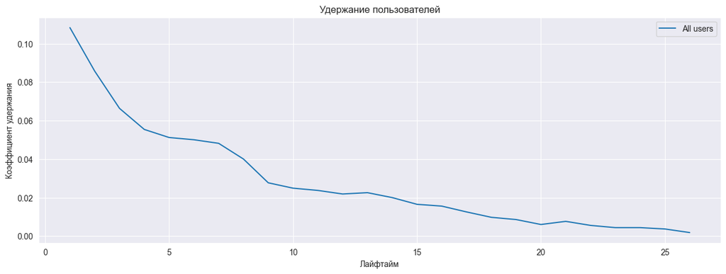

```python
# построим кривую удержания пользователей
sns.set_style('darkgrid')
plot_retention(retention)
```

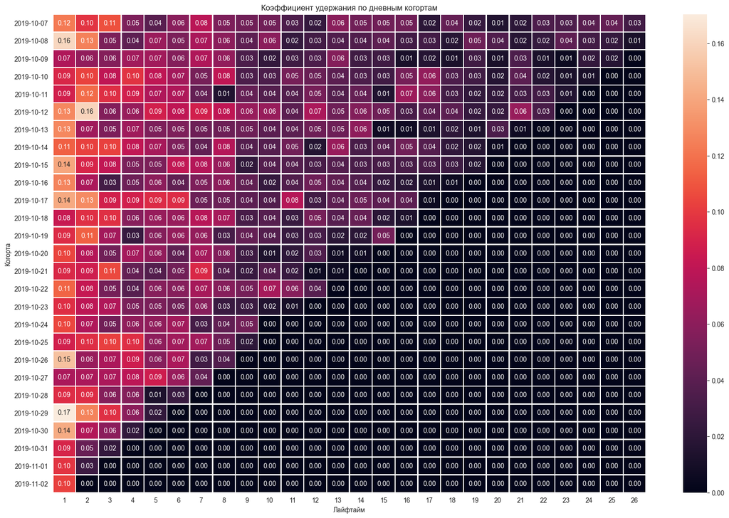

```python
# построим тепловую карту удержания пользователей по дневным когортам
plt.figure(figsize=(20, 13))
sns.heatmap(retention_dt.drop(columns=['cohort_size', 0]),
            annot=True, linewidth=1, fmt='.2f')
plt.xlabel('Лайфтайм')
plt.ylabel('Когорта')
plt.title('Коэффициент удержания по дневным когортам')
plt.show()
```

На графиках видно, что удержание пользователей у мобильного приложения довольно низкое с самого начала.  
Из всех пользователей в целом лишь 11% возвращаются на следующий день после своего первого события, через неделю - 5%, через 2 недели - 2%, через 3 недели - 1%.  
Если анализировать дневные когорты, то на следующий день вернулось больше всех пользователей, впервые зашедших 29 октября (17%), меньше всех - впервые зашедших 9 и 27 октября (7%). Данные по доступным для каждой из когорт последним дням (диагональ карты) колеблятся от 0 до 5%, что также не является высокими показателями.

#### Анализ продолжительности сессий

##### Создание журнала сессий

Для определения продолжительности сессии создадим столбец с разницами во времени между событиями, сгрупированный по пользователям и по дням. Разницами между временем событий, являющиеся достаточно маленькими, чтобы их относить к одной сессии и при этом приходящиеся на разные дни, можно пренебречь, так как их несоизмеримо меньше, чем остальных разниц (максимальное количество таких разностей для группы пользователь-день равно 1).

```python
# добавим в историю посещений столбец с датой посещения
data['dt'] = data['event_time'].dt.date
# отсортируем датасет по пользователию и времени посещения
data.sort_values(by=['user_id', 'event_time'], inplace=True)
# создадим столбец с разницами между событиями
data['diff'] = data.groupby(['user_id', 'dt'])['event_time'].diff()
# переведем столбец из timedelta в дату и время
data['diff'] = data['diff'].dt.seconds
```

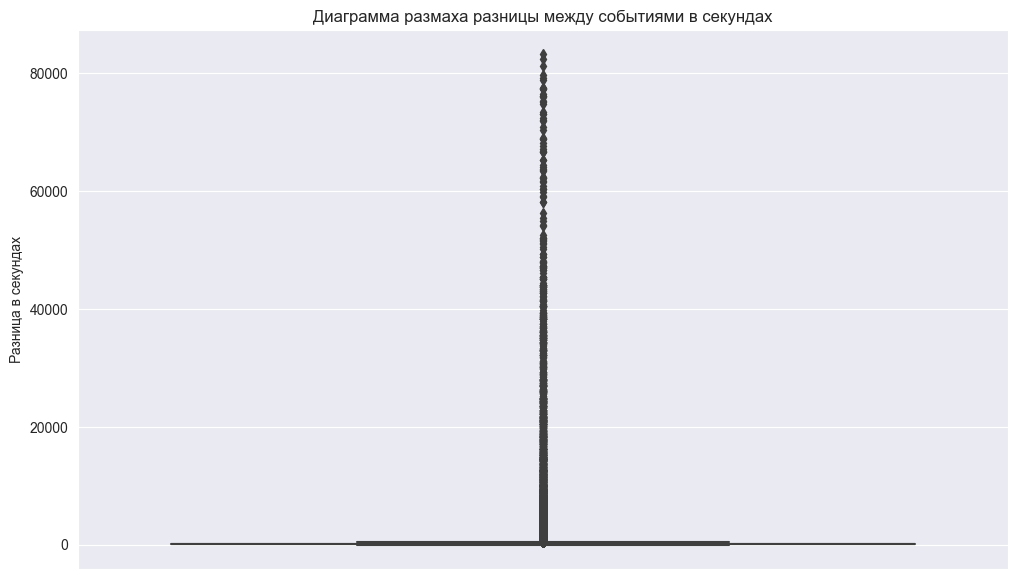

```python
# построим диаграмму размаха для разницы между событиями
plt.figure(figsize=(12,7))
sns.boxplot(data=data, y='diff')
plt.ylabel('Разница в секундах')
plt.title('Диаграмма размаха разницы между событиями в секундах')
plt.show()
```

На графике видно, что между большинством событий в рамках суток промежуток очень маленький, остальные данные являются выбросами. Построим тот же самый график с ограничением на диапазон значений вертикальной оси, чтобы рассмотреть распределение данных.

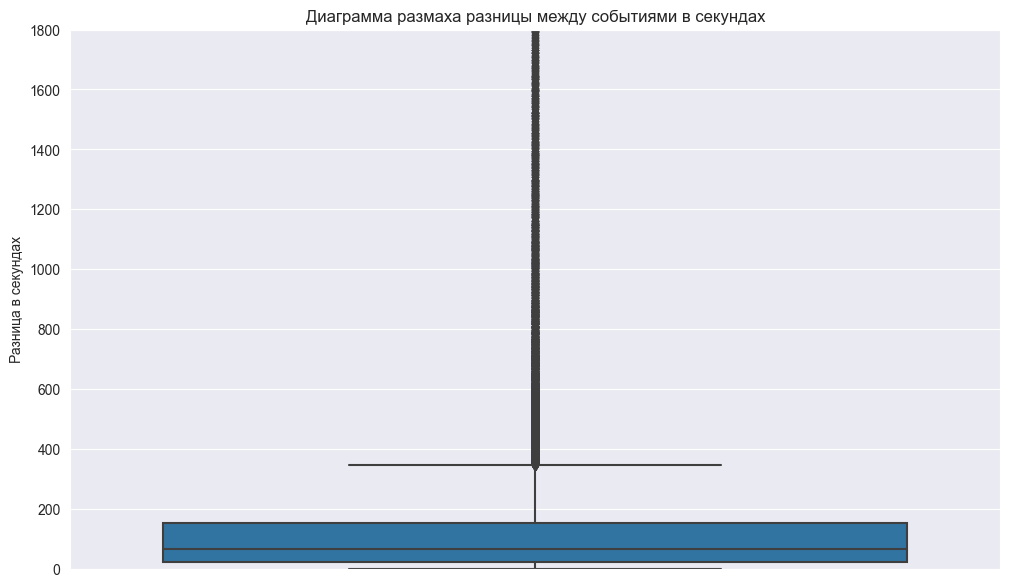

```python
# построим диаграмму размаха с ограничением на вертикальную ось
plt.figure(figsize=(12,7))
sns.boxplot(data=data, y='diff')
plt.ylabel('Разница в секундах')
plt.title('Диаграмма размаха разницы между событиями в секундах')
plt.ylim((0,1800))
plt.show()
```

Максимальное значение верхнего уса составляет менее 400 секунд, данные выше этого порога являются выбросами. Поэтому в качестве значения, выше которого перерыв между событиями означает начало новой сессии, можно взять 420 секунд (7 минут).

```python
# разница между временем событий для каждого из пользователей
diff_timestamp = data.groupby('user_id')['event_time'].diff()
# индексы для каждой новой сессии
new_session = (diff_timestamp.isnull()) | (diff_timestamp > pd.Timedelta('7Min'))
# создаем номера уникальных сессий для каждого из пользователей
data['session_id'] = (
    data.loc[new_session, ['user_id', 'event_time']]
    .groupby('user_id').rank(method='first').astype(int)
)
# заполняем значения для событий в рамках одной сессии
data['session_id'] = data['session_id'].fillna(method='ffill').astype(int)
```

```python
# составим журнал сессий
sessions = data.groupby(['user_id','session_id']).agg({'event_time':['min','max']}).droplevel(1, axis=1)
sessions.columns=['start', 'end']
sessions.reset_index(inplace=True)
sessions['duration'] = sessions['end'] - sessions['start']
# переведем столбец duration из timedelta в дату и время в минутах
sessions['duration'] = sessions['duration'].dt.seconds/60
sessions
```

|  | user_id | session_id | start | end | duration |
| --- | --- | --- | --- | --- | --- |
| 0 | 0001b1d5-b74a-4cbf-aeb0-7df5947bf349 | 1 | 2019-10-07 13:39:45.989359 | 2019-10-07 13:49:41.716617 | 9.916667 |
| 1 | 0001b1d5-b74a-4cbf-aeb0-7df5947bf349 | 2 | 2019-10-09 18:33:55.577963 | 2019-10-09 18:42:22.963948 | 8.450000 |
| 2 | 0001b1d5-b74a-4cbf-aeb0-7df5947bf349 | 3 | 2019-10-21 19:52:30.778932 | 2019-10-21 20:07:30.051028 | 14.983333 |
| 3 | 0001b1d5-b74a-4cbf-aeb0-7df5947bf349 | 4 | 2019-10-22 11:18:14.635436 | 2019-10-22 11:30:52.807203 | 12.633333 |
| 4 | 00157779-810c-4498-9e05-a1e9e3cedf93 | 1 | 2019-10-19 21:34:33.849769 | 2019-10-19 21:46:52.541309 | 12.300000 |
| ... | ... | ... | ... | ... | ... |
| 14162 | fffb9e79-b927-4dbb-9b48-7fd09b23a62b | 41 | 2019-11-02 19:25:53.794029 | 2019-11-02 19:30:50.471310 | 4.933333 |
| 14163 | fffb9e79-b927-4dbb-9b48-7fd09b23a62b | 42 | 2019-11-03 14:32:55.956301 | 2019-11-03 14:48:44.263356 | 15.800000 |
| 14164 | fffb9e79-b927-4dbb-9b48-7fd09b23a62b | 43 | 2019-11-03 15:36:01.007440 | 2019-11-03 15:37:43.995209 | 1.700000 |
| 14165 | fffb9e79-b927-4dbb-9b48-7fd09b23a62b | 44 | 2019-11-03 15:47:43.623778 | 2019-11-03 15:51:57.899997 | 4.233333 |
| 14166 | fffb9e79-b927-4dbb-9b48-7fd09b23a62b | 45 | 2019-11-03 16:07:40.932077 | 2019-11-03 16:08:25.388712 | 0.733333 |

14167 rows × 5 columns

##### Расчет средней и медианной продолжительности сессии

Посчитаем среднюю и медианную продолжительность сессии в целом, построим ящик размаха.

```python
# выводим описательные статистики
sessions['duration'].describe()
```

```
count    14167.000000
mean         5.824072
std          9.227796
min          0.000000
25%          0.000000
50%          2.450000
75%          7.783333
max        128.516667
Name: duration, dtype: float64
```

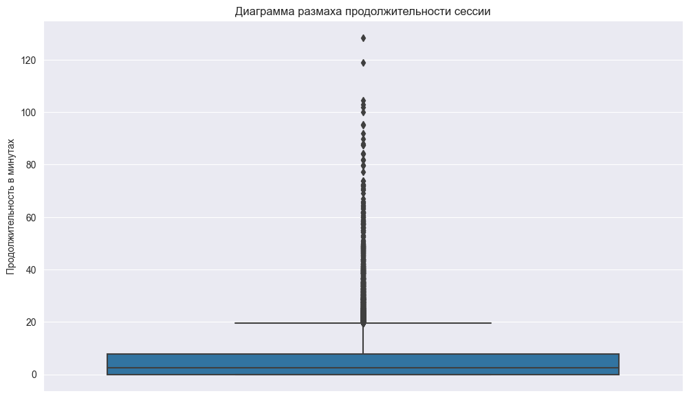

```python
# построим диаграмму размаха с ограничением на вертикальную ось
plt.figure(figsize=(12,7))
sns.boxplot(data=sessions, y='duration')
plt.ylabel('Продолжительность в минутах')
plt.title('Диаграмма размаха продолжительности сессии')
plt.show()
```

Медианная продолжительность сессии составляет 2,45 минуты, средняя выше и составляет 5,8 минуты, что говорит о влиянии выбросов. Максимальная продолжительность сессии составляет 128,5 минут.  
В целом продолжительность сессии невысокая, но для мобильного приложения, целью которого является продажа пользователями ненужных вещей, она является нормальной.

##### Распределение пользователей по продолжительности сессий

Сначала рассчитаем среднюю и медианную продолжительность сессии для каждого пользователя и добавим эту информацию в таблицу с профилями.

```python
# определим медианную и среднюю продолжительность сессии в минутах для каждого пользователя
df2 = sessions.groupby('user_id').agg({'duration':['mean', 'median']}).droplevel(1, axis=1)
df2.columns = ['mean_duration', 'median_duration']
# дополним таблицу профилей пользователей
profiles = profiles.merge(df2, on='user_id')
```

Построим гистограмму распределения пользователей по продолжительности сессий, в качестве примера возьмем только среднюю продолжительность, так как график с медианной мало чем отличается.

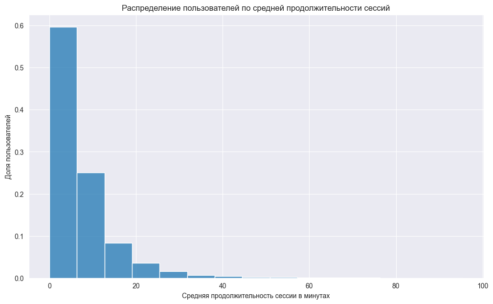

```python
# строим гистограмму распределения пользователей по средней продолжительности сессии
plt.figure(figsize=(12,7))
sns.histplot(data=profiles, x="mean_duration", bins=15, stat='probability')
plt.xlabel('Средняя продолжительность сессии в минутах')
plt.ylabel('Доля пользователей')
plt.title('Распределение пользователей по средней продолжительности сессий')
plt.show()
```

У почти 60% пользователей средняя продолжительность сессии менее 7 минут, у 85% - менее 14 минут. На тех, у кого средняя продолжительность сессии составляет более 20 минут приходится всего лишь около 5%.

```python
# выводим описательные статистики по средней продолжительности
profiles['mean_duration'].describe()
```

```
count    4293.000000
mean        7.201430
std         7.918980
min         0.000000
25%         2.151852
50%         4.944444
75%         9.400000
max        95.433333
Name: mean_duration, dtype: float64
```

```python
# выводим описательные статистики по медианной продолжительности
profiles['median_duration'].describe()
```

```
count    4293.000000
mean        6.572807
std         8.027438
min         0.000000
25%         1.300000
50%         4.266667
75%         8.800000
max        95.433333
Name: median_duration, dtype: float64
```

Средняя и медиана по медианам ожидаемо ниже, чем средняя и медиана по средним.  
Медиана по медианам равна 4,27 минуты, а средняя - 6,57 минут. Это выше, чем обычная медиана и средняя, но к данным показателям стоит относиться с осторожностью, так как они оказываются выше в большинстве случаев.  
У пользователся с самыми высокими средними показателями средняя продолжительность сессии равна 95,43 минутам.

##### Анализ динамики продолжительности сессий

```python
# добавим в журнал сессий дату начала сессии
sessions['dt'] = sessions['start'].dt.date
```

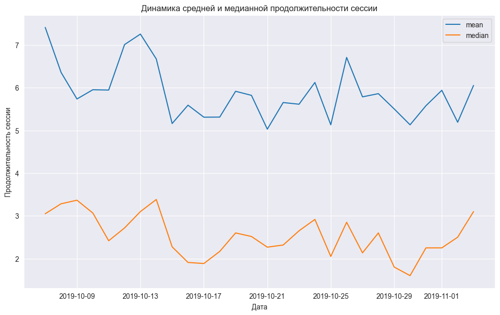

```python
# построим таблицу со средней и мединной продолжительностью сессии по дням
df3 = sessions.groupby('dt').agg({'duration': ['mean', 'median']}).droplevel(1,axis=1)
df3.columns=['mean', 'median']
# построим график динамики продолжительности сессии
df3.plot(figsize=(12,7))
plt.xlabel('Дата')
plt.ylabel('Продолжительность сессии')
plt.title('Динамика средней и медианной продолжительности сессии')
plt.show()
```

На графике видно, что средняя и медианная продолжительности сессии довольно сильно колеблются в течение рассматриваемого периода.  
Длиннее всего сессии в начале периода: в первую неделю средняя поднималась выше 7, а медианная выше 3 минут. Далее в течение всего периода средняя колеблется в диапазоне от 5 до 7 минут, а медианная - от 1,5 до 3 минут.  
В последний день 3 ноября медианная поднялась чуть выше 3 минут, а средняя - 6 минут, то есть можно предположить, что далее будет небольшой рост.

##### Расчет среднего числа сессий на пользователя

```python
print(f'Среднее число сессий на пользователя: {len(sessions)/len(profiles):.1f}')
```

```
Среднее число сессий на пользователя: 3.3
```

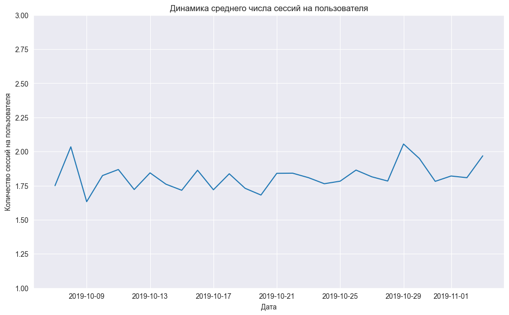

```python
# построим таблицу с средним числом сессий на пользователя за каждый день
df4 = sessions.groupby('dt').agg({'user_id':['count', 'nunique']}).droplevel(1, axis=1)
df4.columns=['count', 'nunique']
df4['session_ratio'] = df4['count']/df4['nunique']
# построим график динамики среднего числа сессий на пользователя
df4['session_ratio'].plot(figsize=(12,7))
plt.ylim((1,3))
plt.xlabel('Дата')
plt.ylabel('Количество сессий на пользователя')
plt.title('Динамика среднего числа сессий на пользователя')
plt.show()
```

Среднее число сессий на пользователя за весь период составляет 3,3 сессии. Это довольно неплохой результат.  
В динамике по дням видно, что количество сессий на пользователя в день меняется несильно, от 1,65 до 2,05. То есть за день каждый пользователь заходил почти 2 раза, это очень хороший результат.  
Этот показатель лучше отображает действительность, чем усредненный показатель за весь период, так как весь период учитывает всех пользователей в равной степени, а динамика по дням лучше учитывает, что некоторые пользователи заходят в приложением активнее других.

При анализе сессий был выявлен ряд особенностей:

- Медианная продолжительность сесси 2,45 минут, а средняя - 5,8. Это нормальный результат;
- Медианная и средняя продолжительность сессии были чуть выше в первую неделю, далее средняя колебалась в диапазоне от 5 до 7 минут, а медианная - от 1,5 до 3 минут. В конце наметился небольшой рост;
- У 60% пользователей длительность сессии составляет менее 7 минут, у 25% - от 7 до 14 минут. Это также нормальный результат;
- Среднее число сессий на пользователя за весь период составило 3,3 сессии. Число сессий на пользователя в день колеблется от 1,65 до 2,05 сессий. Это очень хороший результат.

##### Анализ первых сессий

```python
# построим таблицу с количеством действий по каждому событию для первой сессии
first_session = (
    data[data['session_id']==1]
    .groupby('event_name').agg({'event_time':'count'})
    .rename(columns={'event_time':'event_count'})
    .sort_values(by='event_count', ascending=False)
)
first_session['event_ratio'] = first_session['event_count']/first_session['event_count'].sum()*100
```

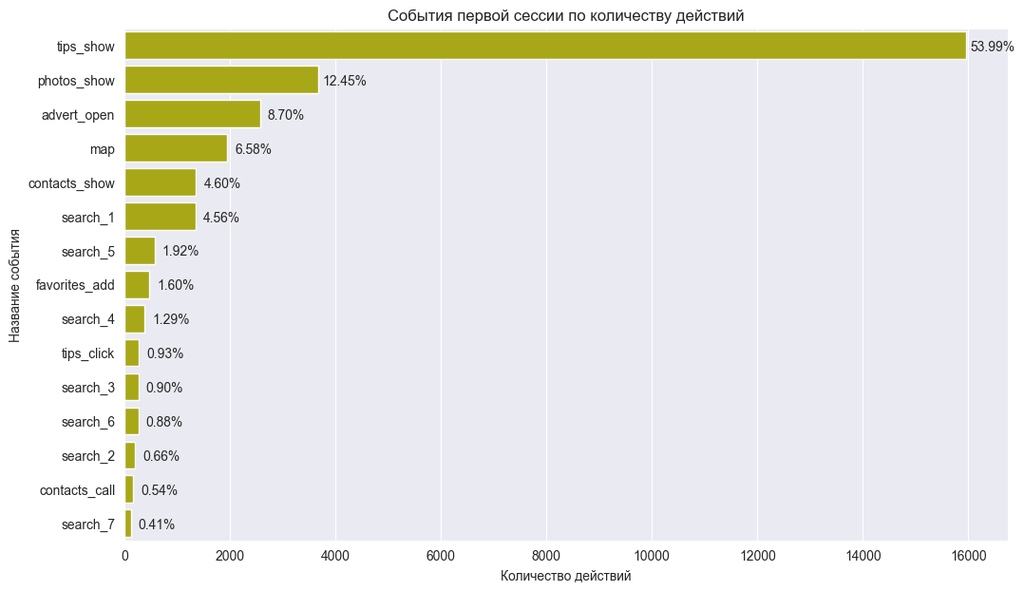

```python
# построим столбчатую диаграмму с количеством действий по каждому событиию по убыванию
plt.figure(figsize=(12,7))
sns.barplot(data = first_session, x='event_count',  y=first_session.index, color='y')
plt.xlabel('Количество действий')
plt.ylabel('Название события')
plt.title('События первой сессии по количеству действий')
r = np.arange(len(first_session))
for x,y,z in zip(first_session['event_ratio'], r, first_session['event_count']):

    label = "{:.2f}%".format(x)

    plt.annotate(label,
                 (z, y),
                 textcoords="offset points",
                 xytext=(20,-4),
                 ha='center')
plt.show()
```

В первых сессиях ключевыми событиями по популярности являются tips_show, photos_show, advert_open, map, contacts_show. В целом очень мало отличий с последующими сессиями.

#### Анализ частоты действий

##### Расчет частоты действий по дням

```python
print(f'Среднее число действий на пользователя: {len(data)/len(profiles):.1f}')
```

```
Среднее число действий на пользователя: 17.3
```

```python
# построим для расчета частоты действий
def event_df(period):
    df = data.groupby(period).agg({'user_id':['count', 'nunique']}).droplevel(1, axis=1)
    df.columns=['events', 'users']
    df['events_ratio'] = df['events']/df['users']
    return df
```

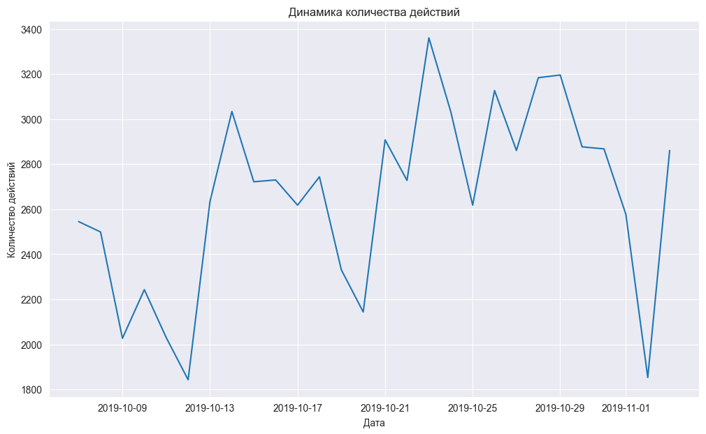

```python
# построим график динамики частоты действий по дням
df5 = event_df('dt')
df5['events'].plot(figsize=(12,7))
plt.xlabel('Дата')
plt.ylabel('Количество действий')
plt.title('Динамика количества действий')
plt.show()
```

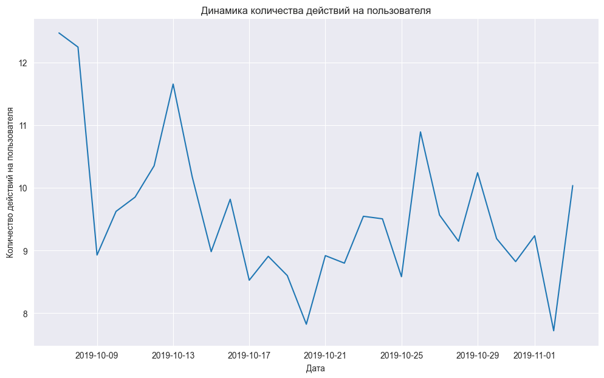

```python
# построим график динамики средней частоты действий на одного пользователя по дням
df5['events_ratio'].plot(figsize=(12,7))
plt.xlabel('Дата')
plt.ylabel('Количество действий на пользователя')
plt.title('Динамика количества действий на пользователя')
plt.show()
```

Среднее количество действий на пользователя за весь период равняется 17,3. Это невысокий показатель, однако более репрезентативными являются показатели частоты действий в динамике.  
Общее количество действий по дням колеблется в диапазоне от 1800 до 3400 в день.  
Дневная частота действий на пользователя колеблется от 7,7 до 12,5. При этом стоит отметить, что наиболее высокие значения были достигнуты в первые два дня, а также в конце первой недели, в то время как общее количество действий в первые два дня было ниже среднего уровня. Это говорит о большем количестве пользователей с более высокой активностью в начале периода. Их активность отразилась и на более высоких показателях продолжительности сессии, которые были проанализированы ранее.

Теперь рассмотрим частоту действий пользователей по дням недели, чтобы лучше понять их поведение.

```python
# создадим столбец week_dt с днем недели совершения действия
data['week_dt'] = data['event_time'].dt.weekday
```

```python
# построим таблицу для расчета частоты действий по дням недели
df_weekday = event_df('week_dt')
df_weekday
```

| week_dt | events | users | events_ratio |
| --- | --- | --- | --- |
| 0 | 11671 | 1060 | 11.010377 |
| 1 | 11145 | 1032 | 10.799419 |
| 2 | 10995 | 1058 | 10.392250 |
| 3 | 10762 | 1074 | 10.020484 |
| 4 | 9969 | 976 | 10.214139 |
| 5 | 9154 | 873 | 10.485682 |
| 6 | 10501 | 975 | 10.770256 |

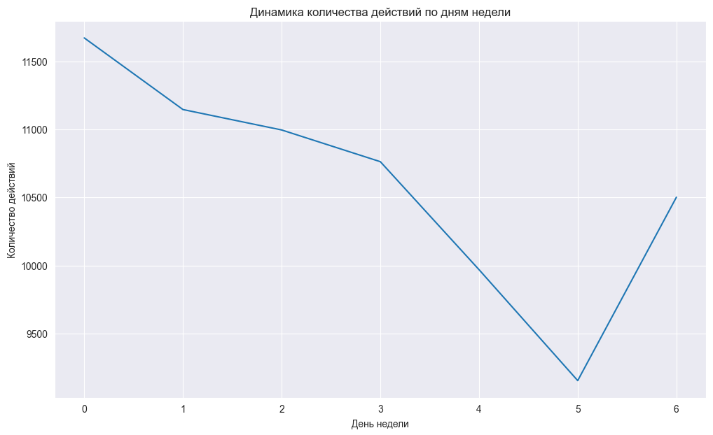

```python
# построим график динамики частоты действий по дням недели
df_weekday['events'].plot(figsize=(12,7))
plt.xlabel('День недели')
plt.ylabel('Количество действий')
plt.title('Динамика количества действий по дням недели')
plt.show()
```

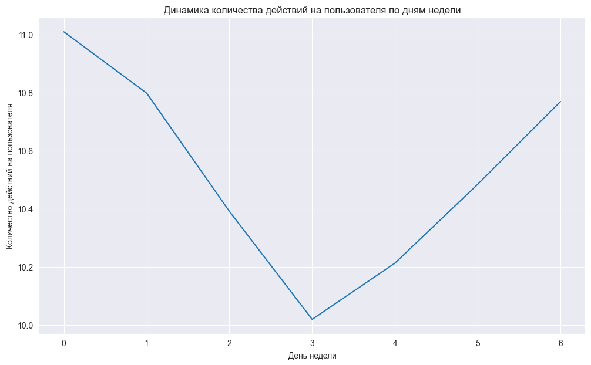

```python
# построим график динамики средней частоты действий на одного пользователя по дням недели
df_weekday['events_ratio'].plot(figsize=(12,7))
plt.xlabel('День недели')
plt.ylabel('Количество действий на пользователя')
plt.title('Динамика количества действий на пользователя по дням недели')
plt.show()
```

Активнее всего пользователи ведут себя по понедельникам, это видно как по общему количеству действий (11 600) и по количестве действий на пользователя (11). Это в том числе объясняется повышенной активностью в воскресенье, возможно люди начинают поиск вещей на выходных, а в понедельник возвращаются за покупкой.  
Меньше всего действий в субботу (9154), но в этот день в приложение заходит и меньше всего пользователей. По соотношению частоты действий к пользователям хуже всех четверг (10,02 действия на пользователя). В целом стоит отметить очень яркно выраженную цикличность, наблюдаемую на графиках.  
Количество действий в целом сильно растет в воскресенье и в понедельник, далее, достигнув пика, со вторника начинает падать вплоть до субботы, после чего, достигнув дна, снова начинает бурный рост.  
Количество действий на пользователя растет с пятницы до понедельника, достигнув пика, далее падает до четверга, после чего, достигнув дна, снова растет.

##### Распределение пользователей по количеству совершенных действий

```python
# определим количество действий для каждого пользователя
df6 = data.groupby('user_id').agg({'event_time':'count'}).rename(columns={'event_time':'event_count'})
# дополним таблицу профилей пользователей
profiles = profiles.merge(df6, on='user_id')
```

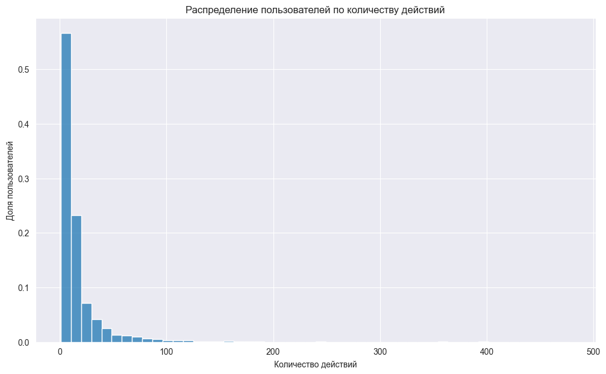

```python
# строим гистограмму распределения пользователей по количеству действий
plt.figure(figsize=(12,7))
sns.histplot(data=profiles, x="event_count", bins=50, stat='probability')
plt.xlabel('Количество действий')
plt.ylabel('Доля пользователей')
plt.title('Распределение пользователей по количеству действий')
plt.show()
```

Более 55% пользователей совершили менее 10 действий за весь рассматриваемый период. Примерно 23% пользователей совершили от 10 до 20 действий. То есть для большинства пользователей характерно значение не более 20 действий, что подтверждается ранее вычисленным средним значением в 17,3 действия.

##### Расчет количества уникальных пользователей в день (DAU)

```python
dau = df5["users"].mean()
print(f'Среднее количество уникальных пользователей в день: {dau:.2f}')
```

```
Среднее количество уникальных пользователей в день: 279.18
```

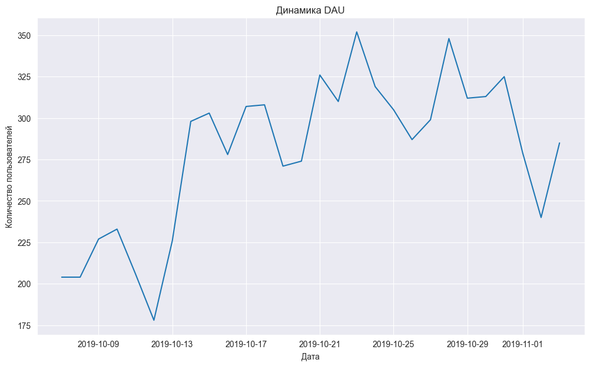

```python
# построим график динамики DAU
df5['users'].plot(figsize=(12,7))
plt.xlabel('Дата')
plt.ylabel('Количество пользователей')
plt.title('Динамика DAU')
plt.show()
```

Среднее количество уникальных пользователей в день за весь период равно 279,18. В динамике данный показатель менялся в диапазоне от 175 до 350.  
Стоит обратить внимание на стабильно низкое количество пользователей в первую неделю по сравнению с тремя последующими. С учетом более высоких показателей частоты действий и продолжительности сессий это вновь говорит о более высокой активности в эту неделю.

```python
# добавим столбец с номером недели
data['week'] = data['event_time'].dt.isocalendar().week
```

```python
# построим таблицу для расчета частоты действий по неделям
df_week_num = event_df('week')
```

```python
wau = df_week_num["users"].mean()
print(f'Среднее количество уникальных пользователей в неделю: {wau:.2f}')
```

```
Среднее количество уникальных пользователей в неделю: 1382.50
```

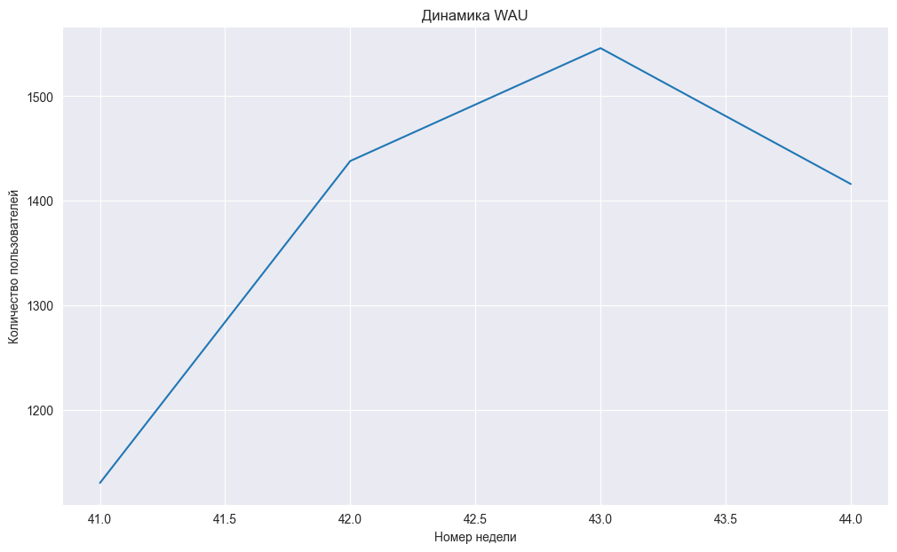

```python
# построим график динамики WAU
df_week_num['users'].plot(figsize=(12,7))
plt.xlabel('Номер недели')
plt.ylabel('Количество пользователей')
plt.title('Динамика WAU')
plt.show()
```

```python
sticky_factor = dau/wau * 100
print(f'Sticky factor: {sticky_factor:.2f}%')
```

```
Sticky factor: 20.19%
```

WAU за весь период равен 1382,5 пользователей. На графике динамики WAU видно, что в первую неделю пользователей было сильно меньше, чем в остальные.  
Sticky factor равен 20,19%, это стандартный результат.

#### Анализ конверсии в просмотр контактов

##### Расчет конверсии в просмотр контактов

Составим функцию для расчета конверсии по лайфтаймам для когорт по различным признакам:

```python
def get_conversion(profiles, data, dimensions=[]):
    # определяем дату и время первого просмотра контактов для каждого пользователя
    contacts_df = (
        data[data['event_name']=='contacts_show'].sort_values(by=['user_id', 'event_time'])
        .groupby('user_id')
        .agg({'event_time': 'first'})
        .reset_index()
    )
    # добавляем данные о просмотре контактов в профили
    result_raw = profiles.merge(
        contacts_df, on='user_id', how='left')

    # рассчитываем лайфтайм для каждого просмотра контактов
    result_raw['lifetime'] = (
        result_raw['event_time'] - result_raw['first_ts']
    ).dt.days

    # группируем по cohort, если в dimensions ничего нет
    if len(dimensions) == 0:
        result_raw['cohort'] = 'All users'
        dimensions = dimensions + ['cohort']

    # функция для группировки таблицы по желаемым признакам
    def group_by_dimensions(df, dims):
        result = df.pivot_table(
            index=dims, columns='lifetime', values='user_id', aggfunc='nunique'
        )
        result = result.fillna(0).cumsum(axis = 1)
        cohort_sizes = (
            df.groupby(dims)
            .agg({'user_id': 'nunique'})
            .rename(columns={'user_id': 'cohort_size'})
        )
        result = cohort_sizes.merge(result, on=dims, how='left').fillna(0)
        # делим каждую «ячейку» в строке на размер когорты
        # и получаем conversion rate
        result = result.div(result['cohort_size'], axis=0)
        result['cohort_size'] = cohort_sizes
        return result

    # получаем таблицу конверсии
    result_grouped = group_by_dimensions(result_raw, dimensions)

    return result_grouped
```

```python
# построим таблицу конверсии по всем пользователям
conversion = get_conversion(profiles, data)
```

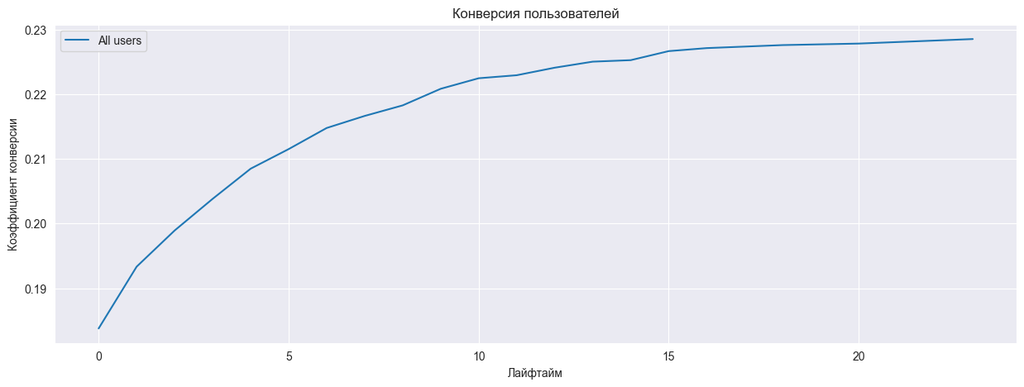

```python
# построим кривую конверсии пользователей
def plot_conversion(conversion):
    conversion.drop(columns='cohort_size').T.plot(grid=True, figsize=(15,5))
    plt.legend()
    plt.xlabel('Лайфтайм')
    plt.ylabel('Коэффициент конверсии')
    plt.title('Конверсия пользователей')
    plt.show()
plot_conversion(conversion)
```

```python
print(f'Коэффициент конверсии: {(conversion[23]).item()*100:.2f}%')
```

```
Коэффициент конверсии: 22.85%
```

```python
print(f'Доля пользователей, просмотревших контакты в первый день посещения:\
 {(conversion[0]/conversion[23]).item()*100:.2f}%')
```

```
Доля пользователей, просмотревших контакты в первый день посещения: 80.43%
```

Конверсия в целевое действие составила 22,85% от всех пользователей, что является хорошим показателем.  
На графике видно, что 18,3% всех пользователей просмотрели контакты в первый день своего посещения, что составляет 80,43% от всех пользователей, просмотревших контакты. Это высокий показатель, который говорит о том, что из нашедших интересующую вещь пользователей абсолютное большинство делают это в первый же день.

##### Анализ пользовательского пути до просмотра контактов

Рассмотрим место каждого события в пользовательском пути.

```python
# создадим таблицу с количеством действий и пользователей по каждому событию
df7 = (
    data.groupby('event_name', as_index=False)
    .agg({'user_id':['count', 'nunique']})
    .droplevel(1, axis=1)
)
df7.columns=['event_name', 'event_count', 'user_count']
df7.sort_values(by='user_count', ascending=False, inplace=True)
df7['event_ratio'] = round(df7['event_count']/df7['event_count'].sum()*100, 2)
```

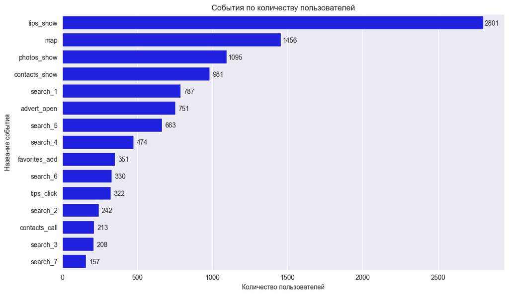

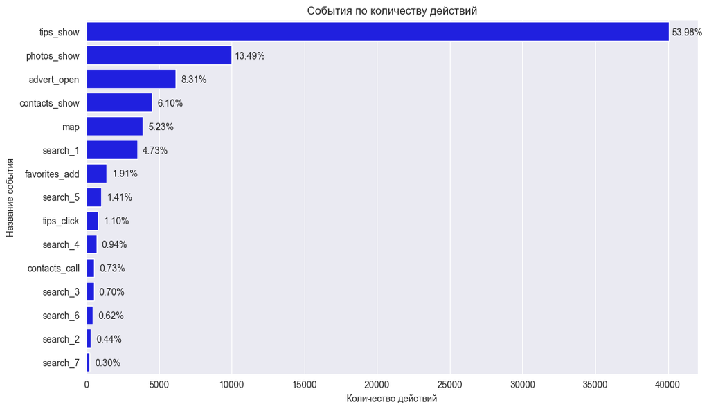

```python
# построим стобчатую диаграмму с количеством пользователей по каждому событию по убыванию
plt.figure(figsize=(12,7))
sns.barplot(data = df7, x='user_count',  y='event_name', color='b')
plt.xlabel('Количество пользователей')
plt.ylabel('Название события')
plt.title('События по количеству пользователей')
r = np.arange(len(df7))
for x,y in zip(df7['user_count'], r):

    label = "{:.0f}".format(x)

    plt.annotate(label,
                 (x, y),
                 textcoords="offset points",
                 xytext=(13,-4),
                 ha='center')

# построим столбчатую диаграмму с количеством действий по каждому событиию по убыванию
df9 = df7.sort_values(by='event_count', ascending=False)
plt.figure(figsize=(12,7))
sns.barplot(data = df9, x='event_count',  y='event_name', color='b')
plt.xlabel('Количество действий')
plt.ylabel('Название события')
plt.title('События по количеству действий')
r = np.arange(len(df9))
for x,y,z in zip(df9['event_ratio'], r, df9['event_count']):

    label = "{:.2f}%".format(x)

    plt.annotate(label,
                 (z, y),
                 textcoords="offset points",
                 xytext=(20,-4),
                 ha='center')
plt.show()
```

На 1-ом месте по количеству пользователей и действий с большим отрывом находится tips_show. Это означает, что это скорее всего автоматически всплывающие рекомендации, поэтому на это событие при анализе ориентироваться не стоит.  
Целевое событие contacts_show находится на 4-ом месте по количеству действий и пользователей. Учитывая, что событий всего 15, это событие можно считать довольно распространенным. События, которые находятся в рейтингах сильно позади, с более низкой вероятностью происходят до contacts_show. Поэтому если и есть возможность построить цепочки событий, то они будут состоять из 3-4 действий.

Посчитаем, какое количество событий совершает большинство пользователей.

```python
# создаем маску для признака contacts_show
data['contacts_show'] = data['event_name']=='contacts_show'

# добавим в профили пользователей данные о количестве событий и информацией о совершении contacts_show
df_show = (
    data.groupby('user_id')
    .agg({'event_name':'nunique', 'contacts_show':'max'})
    .rename(columns={'event_name':'event_nunique'})
)
profiles = profiles.merge(df_show, on='user_id')
```

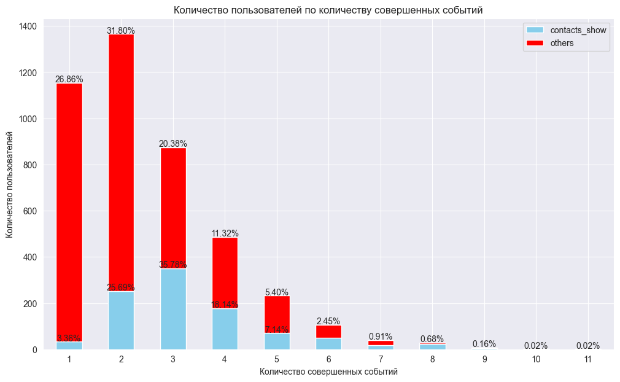

```python
# создадим таблицу с количеством пользователей, совершивших определенное количество событий
df8 = (
    profiles
    .groupby('event_nunique')
    .agg({'event_nunique':'count', 'contacts_show':'sum'})
    .rename(columns={'event_nunique':'user_count'})
)
df8['event_ratio'] = round(df8['user_count']/df8['user_count'].sum()*100, 2)
df8['contact_ratio'] = round(df8['contacts_show']/df8['contacts_show'].sum()*100, 2)
df8['others'] = df8['user_count']-df8['contacts_show']

# построим столбчатую диаграмму с распределением пользователей по количеству совершенных событий
(df8[['contacts_show', 'others']]
 .plot(kind='bar', stacked=True, color=['skyblue', 'red'], figsize=(12,7), rot=360))
plt.xlabel('Количество совершенных событий')
plt.ylabel('Количество пользователей')
plt.title('Количество пользователей по количеству совершенных событий')
r = np.arange(len(df8))
for x,y,z in zip(r, df8['event_ratio'], df8['user_count']):

    label = "{:.2f}%".format(y)

    plt.annotate(label,
                 (x, z),
                 textcoords="offset points",
                 xytext=(0,1),
                 ha='center')
r = np.arange(5)
for x,y,z in zip(r, df8['contact_ratio'], df8['contacts_show']):

    label = "{:.2f}%".format(y)

    plt.annotate(label,
                 (x, z),
                 textcoords="offset points",
                 xytext=(0,1),
                 ha='center')
plt.show()
```

На графике видно, что 58,6% пользователей за весь период совершили не более 2 разных событий, еще 31,7% совершили 3 или 4 различных события. Для данного мобильного приложения нельзя говорить о наличии единой цепочки событий, по которой двигается большинство пользователей.  
35,78% просматривавших контакты пользователей совершили 3 различных события, 25,69% - 2 события, 18,14% - события. Таким образом, абсолютное большинство пользователей совершают в общей сложности от 2 до 4 событий. Это также говорит о возможности построения отдельных цепочек в 3-4 дейстивя, которые могут иметь смысл при анализе конверсии в просмотр контактов.

Посмотрим, с каких событий чаще всего начинаются пользовательсие сессии.

```python
df_first = (
    data.groupby(['user_id','session_id']).agg({'event_name':'first'})
    .groupby('event_name').agg({'event_name':'count'}))
df_first.columns=['first_count']
df_first.sort_values(by='first_count', ascending=False, inplace=True)
df_first
```

| event_name | first_count |
| --- | --- |
| tips_show | 5801 |
| photos_show | 2274 |
| search_1 | 1665 |
| map | 1482 |
| contacts_show | 839 |
| advert_open | 665 |
| search_4 | 542 |
| favorites_add | 200 |
| search_7 | 177 |
| search_6 | 151 |
| search_5 | 124 |
| tips_click | 107 |
| search_3 | 88 |
| search_2 | 52 |

Пользовательские сессии чаще всего начинаются с photos_show, затем идет search_1, map, contacts_show, advert_open.

Исходя из проведенного анализа, в целом можно выделить всего 5 событий, из которых целесообразно пытаться выстраивать цепочки событий. Это photos_show, search_1, map, contacts_show, advert_open.

```python
# построим профили пользователей с масками событий
user_way = data[['user_id']]
for event in ['contacts_show', 'photos_show', 'search_1', 'map', 'advert_open']:
    user_way[event] = data['event_name']==event
user_way = user_way.groupby('user_id').agg('max')
user_way
```

| user_id | contacts_show | photos_show | search_1 | map | advert_open |
| --- | --- | --- | --- | --- | --- |
| 0001b1d5-b74a-4cbf-aeb0-7df5947bf349 | False | False | False | True | False |
| 00157779-810c-4498-9e05-a1e9e3cedf93 | True | True | True | False | True |
| 00463033-5717-4bf1-91b4-09183923b9df | False | True | False | False | False |
| 004690c3-5a84-4bb7-a8af-e0c8f8fca64e | False | False | False | True | True |
| 00551e79-152e-4441-9cf7-565d7eb04090 | True | True | True | False | False |
| ... | ... | ... | ... | ... | ... |
| ffab8d8a-30bb-424a-a3ab-0b63ebbf7b07 | False | False | False | True | False |
| ffc01466-fdb1-4460-ae94-e800f52eb136 | True | True | False | False | False |
| ffcf50d9-293c-4254-8243-4890b030b238 | False | False | False | True | False |
| ffe68f10-e48e-470e-be9b-eeb93128ff1a | True | True | True | False | False |
| fffb9e79-b927-4dbb-9b48-7fd09b23a62b | True | False | False | True | False |

4293 rows × 5 columns

```python
# составим функцию для создания датафреймов с воронками из 3 событий (сквозная и от предыдущего этапа)
def df_funnel_3(event_1, event_2, event_3):
    a = len(user_way[user_way[event_1]==True])
    b = (len(user_way[(user_way[event_1]==True)
                      & (user_way[event_2]==True)]))
    c = (len(user_way[(user_way[event_1]==True)
                      & (user_way[event_2]==True)
                      & (user_way[event_3]==True)]))
    d = (len(user_way[(user_way[event_1]==True)
                      & (user_way[event_3]==True)]))
    df1 = pd.DataFrame([a, b, c], index=[event_1, event_2, event_3], columns=['user_cnt'])
    df1['cr, %'] = round(df1['user_cnt']/df1.loc[event_1, 'user_cnt']*100, 2)
    df1['cr_step, %'] = round((df1['user_cnt'].pct_change() + 1)*100, 2)
    df2 = pd.DataFrame([a, b, d], index=[event_1, event_2, event_3], columns=['user_cnt'])
    df2['cr, %'] = round(df2['user_cnt']/df2.loc[event_1, 'user_cnt']*100, 2)
    return df1, df2
```

```python
# составим функцию для создания датафреймов с воронками из 4 событий (сквозная и от предыдущего этапа)
def df_funnel_4(event_1, event_2, event_3, event_4):
    a = len(user_way[user_way[event_1]==True])
    b = (len(user_way[(user_way[event_1]==True)
                      & (user_way[event_2]==True)]))
    c = (len(user_way[(user_way[event_1]==True)
                      & (user_way[event_2]==True)
                      & (user_way[event_3]==True)]))
    d = (len(user_way[(user_way[event_1]==True)
                      & (user_way[event_2]==True)
                      & (user_way[event_3]==True)
                      & (user_way[event_4]==True)]))
    e = (len(user_way[(user_way[event_1]==True)
                      & (user_way[event_3]==True)]))
    f = (len(user_way[(user_way[event_1]==True)
                      & (user_way[event_4]==True)]))
    df1 = pd.DataFrame([a, b, c, d], index=[event_1, event_2, event_3, event_4], columns=['user_cnt'])
    df1['cr, %'] = round(df1['user_cnt']/df1.loc[event_1, 'user_cnt']*100, 2)
    df1['cr_step, %'] = round((df1['user_cnt'].pct_change() + 1)*100, 2)
    df2 = pd.DataFrame([a, b, e, f], index=[event_1, event_2, event_3, event_4], columns=['user_cnt'])
    df2['cr, %'] = round(df2['user_cnt']/df2.loc[event_1, 'user_cnt']*100, 2)
    return df1, df2
```

Попробуем рассмотреть воронки с map в качестве первого события.

```python
funnel_step, funnel_through = df_funnel_4('map', 'photos_show', 'advert_open', 'contacts_show')
```

```python
funnel_step
```

|  | user_cnt | cr, % | cr_step, % |
| --- | --- | --- | --- |
| map | 1456 | 100.00 | NaN |
| photos_show | 5 | 0.34 | 0.34 |
| advert_open | 3 | 0.21 | 60.00 |
| contacts_show | 2 | 0.14 | 66.67 |

```python
funnel_through
```

|  | user_cnt | cr, % |
| --- | --- | --- |
| map | 1456 | 100.00 |
| photos_show | 5 | 0.34 |
| advert_open | 517 | 35.51 |
| contacts_show | 289 | 19.85 |

```python
funnel_step, funnel_through = df_funnel_4('map', 'search_1', 'advert_open', 'contacts_show')
```

```python
funnel_step
```

|  | user_cnt | cr, % | cr_step, % |
| --- | --- | --- | --- |
| map | 1456 | 100.00 | NaN |
| search_1 | 5 | 0.34 | 0.34 |
| advert_open | 4 | 0.27 | 80.00 |
| contacts_show | 2 | 0.14 | 50.00 |

```python
funnel_through
```

|  | user_cnt | cr, % |
| --- | --- | --- |
| map | 1456 | 100.00 |
| search_1 | 5 | 0.34 |
| advert_open | 517 | 35.51 |
| contacts_show | 289 | 19.85 |

```python
funnel_step, funnel_through = df_funnel_3('map', 'advert_open', 'contacts_show')
```

```python
funnel_step
```

|  | user_cnt | cr, % | cr_step, % |
| --- | --- | --- | --- |
| map | 1456 | 100.00 | NaN |
| advert_open | 517 | 35.51 | 35.51 |
| contacts_show | 86 | 5.91 | 16.63 |

```python
funnel_through
```

|  | user_cnt | cr, % |
| --- | --- | --- |
| map | 1456 | 100.00 |
| advert_open | 517 | 35.51 |
| contacts_show | 289 | 19.85 |

Если map является первым событием, то в качестве воронки можно рассматривать лишь вариант map --> advert_open --> contacts_show. Коэффициент конверсии воронки от предыдущего этапа из map в contacts_show равен 5,91%, это довольно плохой результат. Из всех пользователей, открывавших карту, просмотрели контакты только 19,85%. Это ниже, чем общий показатель конверсии в просмотр контактов. Возможно, map вообще не стоит включать в воронку.

Попробуем рассмотреть воронки с photos_show в качестве первого события.

```python
funnel_step, funnel_through = df_funnel_4('photos_show', 'search_1', 'advert_open', 'contacts_show')
```

```python
funnel_step
```

|  | user_cnt | cr, % | cr_step, % |
| --- | --- | --- | --- |
| photos_show | 1095 | 100.00 | NaN |
| search_1 | 643 | 58.72 | 58.72 |
| advert_open | 49 | 4.47 | 7.62 |
| contacts_show | 25 | 2.28 | 51.02 |

```python
funnel_through
```

|  | user_cnt | cr, % |
| --- | --- | --- |
| photos_show | 1095 | 100.00 |
| search_1 | 643 | 58.72 |
| advert_open | 73 | 6.67 |
| contacts_show | 339 | 30.96 |

```python
funnel_step, funnel_through = df_funnel_3('photos_show', 'search_1', 'contacts_show')
```

```python
funnel_step
```

|  | user_cnt | cr, % | cr_step, % |
| --- | --- | --- | --- |
| photos_show | 1095 | 100.00 | NaN |
| search_1 | 643 | 58.72 | 58.72 |
| contacts_show | 191 | 17.44 | 29.70 |

```python
funnel_through
```

|  | user_cnt | cr, % |
| --- | --- | --- |
| photos_show | 1095 | 100.00 |
| search_1 | 643 | 58.72 |
| contacts_show | 339 | 30.96 |

Если photos_show является первым событием, то в качестве воронки можно рассматривать лишь вариант photos_show --> search_1 --> contacts_show. Коэффициент конверсии воронки от предыдущего этапа из photos_show в contacts_show равен 17,44%, это хороший результат. Из всех пользователей, просмотревших фото, просмотрели контакты 30,96%.

Попробуем рассмотреть воронки с search_1 в качестве первого события.

```python
funnel_step, funnel_through = df_funnel_4('search_1', 'photos_show', 'advert_open', 'contacts_show')
```

```python
funnel_step
```

|  | user_cnt | cr, % | cr_step, % |
| --- | --- | --- | --- |
| search_1 | 787 | 100.00 | NaN |
| photos_show | 643 | 81.70 | 81.70 |
| advert_open | 49 | 6.23 | 7.62 |
| contacts_show | 25 | 3.18 | 51.02 |

```python
funnel_through
```

|  | user_cnt | cr, % |
| --- | --- | --- |
| search_1 | 787 | 100.00 |
| photos_show | 643 | 81.70 |
| advert_open | 54 | 6.86 |
| contacts_show | 237 | 30.11 |

```python
best_funnel, funnel_through = df_funnel_3('search_1', 'photos_show', 'contacts_show')
```

```python
best_funnel
```

|  | user_cnt | cr, % | cr_step, % |
| --- | --- | --- | --- |
| search_1 | 787 | 100.00 | NaN |
| photos_show | 643 | 81.70 | 81.7 |
| contacts_show | 191 | 24.27 | 29.7 |

```python
funnel_through
```

|  | user_cnt | cr, % |
| --- | --- | --- |
| search_1 | 787 | 100.00 |
| photos_show | 643 | 81.70 |
| contacts_show | 237 | 30.11 |

Если search_1 является первым событием, то в качестве воронки можно рассматривать лишь вариант search_1 --> photos_show --> contacts_show. Коэффициент конверсии воронки от предыдущего этапа из search_1 в contacts_show равен 24,27%, отличный результат, это выше, чем конверсия в целом. Из всех пользователей, выполнивших search_1, просмотрели контакты 30,11%. Однако важно понимать, что из всех просматривавших контакты пользователей в эту воронку попало лишь примерно 20%. Это еще раз говорит об отсутствии какой-либо общей или близкой к ней воронки.

С advert_open в качестве первого события можно рассмотреть только воронку advert_open --> map --> contacts_show.

```python
funnel_step, funnel_through = df_funnel_3('advert_open', 'map', 'contacts_show')
```

```python
funnel_step
```

|  | user_cnt | cr, % | cr_step, % |
| --- | --- | --- | --- |
| advert_open | 751 | 100.00 | NaN |
| map | 517 | 68.84 | 68.84 |
| contacts_show | 86 | 11.45 | 16.63 |

```python
funnel_through
```

|  | user_cnt | cr, % |
| --- | --- | --- |
| advert_open | 751 | 100.00 |
| map | 517 | 68.84 |
| contacts_show | 138 | 18.38 |

Воронка стала лучше по сравнению с той, где map был в качестве первого события, так как advert_open в целом выполнили меньшее количество пользователей. Однако коэффициент конверсии воронки от предыдущего этапа из advert_open в contacts_show равен 11,45%. Из всех пользователей, просматривавших карточку объявления, просмотрели контакты лишь 18,38%. Это ниже, чем общая конверсия в contacts_show.

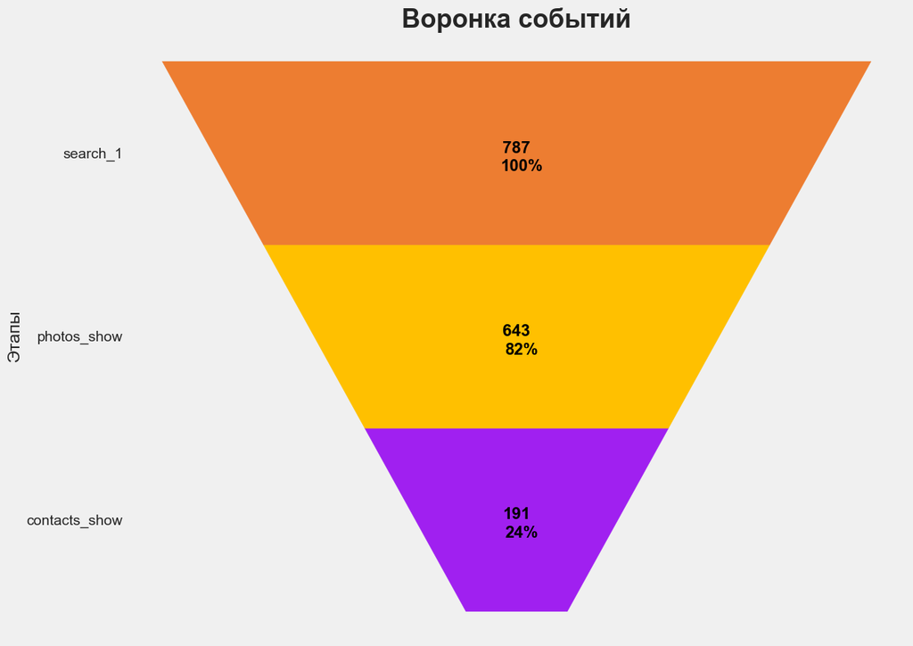

```python
# визуализируем воронку search_1-->photos_show-->contacts_show
with plt.style.context('fivethirtyeight'):
    colors = ['#a020f0', '#ffc000', '#ed7d31']
    fig = plt.figure(figsize=(12,10))

    plt.fill_betweenx(y=[1, 6], x1=[10,12], x2=[8,6], color=colors[0]);
    plt.fill_betweenx(y=[6, 11], x1=[12,14], x2=[6,4], color=colors[1]);
    plt.fill_betweenx(y=[11, 16], x1=[14,16], x2=[4,2], color=colors[2]);

    plt.xticks([],[]);
    plt.yticks([3.5, 8.5, 13.5], best_funnel.index[::-1]);

    for y, value in zip([3.5, 8.5, 13.5], best_funnel['user_cnt'][::-1]):
        plt.text(9, y, value, fontsize=16, fontweight='bold', color='black', ha='center');

    for y, value in zip([3, 8, 13], best_funnel['cr, %'][::-1]):
        value = '{:.0f}%'.format(value)
        plt.text(9.1, y, value, fontsize=16, fontweight='bold', color='black', ha='center');

    plt.grid(visible=False);
    plt.ylabel('Этапы');

    plt.title('Воронка событий', loc='center', fontsize=25, fontweight='bold');
    plt.show()
```

В ходе анализа конверсии в просмотр контактов был выявлен следующий ряд особенностей:

- Конверсия в целевое действие составила 22,85% от всех пользователей, что является хорошим показателем;
- 80,43% от всех пользователей, просмотревших контакты, сделали это в первый день своего посещения;
- По сравнению с другими вариантами больше всего пользователей совершили 2 различных события (31,8%);
- Среди просматривавших контакты по сравнению с другими вариантами больше всего пользователей совершили 3 различных события (35,78%);
- Пользовательский путь до целевого действия не является однородным и какая-либо общая воронка событий отсутствует;
- Воронки из 4 событий показывают конверию не более 4%;
- Лучшей воронкой из 3 событий является воронка search_1-->photos_show-->contacts_show, конверсия в просмотры контактов составила 24%. Однако в эту воронку попали лишь 20% от всех просматривавших контакты пользователей.

В ходе исследовательского анализа был выявлен следующий ряд особенностей:

- Удержание пользователей у мобильного приложения довольно низкое с самого начала;
- Из всех пользователей в целом лишь 11% возвращаются на следующий день после своего первого события, через неделю - 5%, через 2 недели - 2%, через 3 недели - 1%;
- Медианная продолжительность сесси 2,45 минут, а средняя - 5,8. Это нормальный результат;
- Медианная и средняя продолжительность сессии были чуть выше в первую неделю, далее средняя колебалась в диапазоне от 5 до 7 минут, а медианная - от 1,5 до 3 минут. В конце наметился небольшой рост;
- У 60% пользователей длительность сессии составляет менее 7 минут, у 25% - от 7 до 14 минут. Это также нормальный результат;
- Среднее число сессий на пользователя за весь период составило 3,3 сессии. Число сессий на пользователя в день колеблется от 1,65 до 2,05 сессий. Это очень хороший результат;
- Среднее число действий на пользователя за весь период равно 17,3;
- Частота действий пользователя в день колеблется от 7,7 до 12,5, это хороший показатель активности зашедших в приложение пользователей;
- Среднее количество уникальных пользователей в день 279,18;
- В первую неделю абсолютное количество действий ниже, при этом максимум частоты действий пользователя (более 12 действий) в день был достигнут в первые два дня. Количество уникальных пользователей в день в первую неделю ниже среднего и последующих недель (во все дни в диапазоне от 175 до 225). Это говорит о более высокой активности пользователей в начале периода;
- Конверсия в целевое действие составила 22,85% от всех пользователей, что является хорошим показателем;
- 80,43% от всех пользователей, просмотревших контакты, сделали это в первый день своего посещения;
- По сравнению с другими вариантами больше всего пользователей совершили 2 различных события (31,8%);
- Среди просматривавших контакты по сравнению с другими вариантами больше всего пользователей совершили 3 различных события (35,78%);
- Пользовательский путь до целевого действия не является однородным и какая-либо общая воронка событий отсутствует;
- Воронки из 4 событий показывают конверию не более 4%;
- Лучшей воронкой из 3 событий является воронка search_1-->photos_show-->contacts_show, конверсия в просмотры контактов составила 24%. Однако в эту воронку попали лишь 20% от всех просматривавших контакты пользователей.

### Сегментация пользователей и приоритизация сегментов

#### Выбор признака сегментации

Рассчитаем корреляцию между продолжительностью сессии и частотой действий:

```python
# добавим в журнал сессий количество действий
df10 = (
    data.groupby(['user_id', 'session_id'], as_index=False)
    .agg({'event_name':'count'})
    .rename(columns={'event_name': 'event_count'}))
sessions = sessions.merge(df10, on=['user_id','session_id'])
```

```python
print(f'Коэффициент корреляции между длительностью сессии и количеством действий:\
 {sessions["duration"].corr(sessions["event_count"]):.2f}')
```

```
Коэффициент корреляции между длительностью сессии и количеством действий: 0.82
```

Зависимость между длительностью сессии и количеством действий высокая, поэтому эти признаки влияют на другие переменные похожим образом, и рассматривать их вместе как один признак для сегментации не имеет смысла.  
В измерении продолжительности сессии есть некоторая погрешность, так как точных данных нет и она была вычислена исходя из промежутков между действиями. Поэтому использование этого признака для сегментации может привести к некоторым неточностям.  
Лучше в качестве признака сегментации рассмотреть частоту действий, так как этот признак задан в исходных данных. Из-за высокой корреляции с длительностью сессии по нему заодно можно судить и о характере влияния продолжительности сессии на коэффициент удержания и конверсии.

Полезность сегментации именно по данному признаку состоит в том, что в случае выявления больших различий по конверсии и удержанию между сегментами заказчик сможет сфокусироваться на поведении сегмента, который показывает себя лучше всего, а также на его отличиях с теми сегментами, которые показывают себя хуже всего. В случае с частотой действий причина разницы может заключаться в том, что пользователи из сегментов с худшими показателями совершают не те события, которые совершаются пользователями из сегментов с лучшими показателями. Если разница в конверсии и удержании будет выявлена, то будет иметь смысл сосредоточить внимание на сравнении пользовательских путей отдельных сегментов, а не всех пользователей сразу.  
Предполагается, что у пользователей с более высокой частотой более высокие конверсия и удержание.

Разделим количество пользователей на 4 сегмента по квартилям частоты действий.

```python
# построим функцию для сегментации
def categorize_count(event_count):
    if event_count<=profiles['event_count'].quantile(0.25):
        return 'Низкая частота'
    elif profiles['event_count'].quantile(0.25)<event_count<=profiles['event_count'].quantile(0.5):
        return 'Средняя частота'
    elif profiles['event_count'].quantile(0.5)<event_count<=profiles['event_count'].quantile(0.75):
        return 'Высокая частота'
    else:
        return 'Очень высокая частота'

# применим функцию для создания нового столбца с названием сегмента
profiles['segment'] = profiles['event_count'].apply(categorize_count)
```

```python
profiles.groupby('segment').agg({'user_id':'count'})
```

| segment | user_id |
| --- | --- |
| Высокая частота | 997 |
| Низкая частота | 1140 |
| Очень высокая частота | 1051 |
| Средняя частота | 1105 |

По количеству пользователей все сегменты примерно одинаковые, задействованы все пользователи, сегменты не пересекаются.

#### Характеристика сегментов по коэффициенту удержания

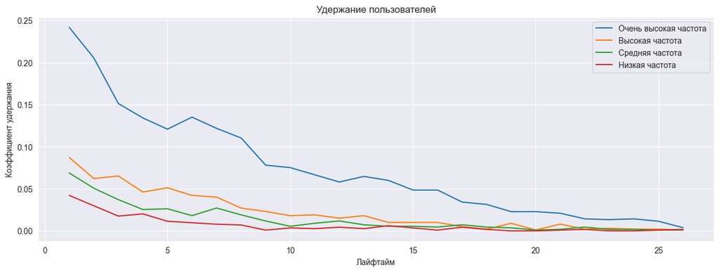

```python
# построим таблицу удержания для сегментов
retention_seg = get_retention(profiles, data, 'segment').sort_values(by=1, ascending=False)
# построим кривые удержания для сегментов
plot_retention(retention_seg)
```

Лучше всех с большим отрывом показывает себя сегмент с очень высокой частотой действий. Это справедливно на протяжении всего лайфтайма пользователя. Удержание на первый день у данного сегмента составляет примерно 24%.  
Далее идут высокая, средняя и низкая частота действий. Удержание на первый день высокой частоты составляет 9%, у средней - 7%, у низкой - 4%. Под конец лайфтайма они становятся одинаковыми.

#### Характеристика сегментов по коэффициенту конверсии

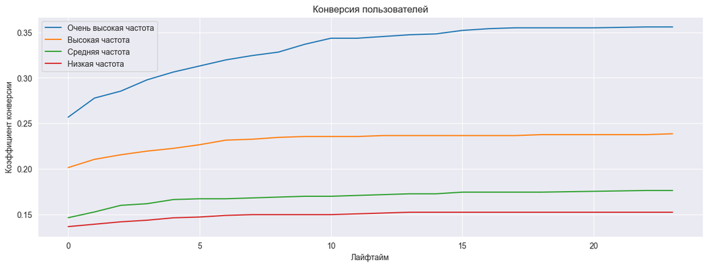

```python
# построим таблицу конверсии для сегментов
conversion_seg = get_conversion(profiles, data, 'segment').sort_values(by=0, ascending=False)
# построим кривые конверсии для сегментов
plot_conversion(conversion_seg)
```

```python
round(conversion_seg[[23]], 2).sort_values(by=23, ascending=False)
```

| segment | 23.0 |
| --- | --- |
| Очень высокая частота | 0.36 |
| Высокая частота | 0.24 |
| Средняя частота | 0.18 |
| Низкая частота | 0.15 |

Лучше всех с большим отрывом показывает себя сегмент с очень высокой частотой действий. Это справедливно на протяжении всего лайфтайма пользователя. Далее идут высокая, средняя и низкая частота действий.  
У очень высокой частоты также самый сильный рост конверсии, который замедляется лишь к 15 лайфтайму. У высокой частоты рост замедляется с 8 лайфтайма, у остальных - с 5.  
Общая конверсия у очень высокой частоты - 36%, высокой - 24%, средней - 18%, низкой - 15%.  
Тенденция на высокую конверсию в первый день посещения приложения сохраняется во всех сегментах. Однако чем меньше частота, тем большая доля пользователей из всех просмотревших контакты сделала это в первый день.

Проритизация сегментов по удержанию и конверсии:

| Частота действий | Удержание в 1-й день | Конверсия |
| --- | --- | --- |
| Очень высокая | 24% | 36% |
| Высокая | 9% | 24% |
| Средняя | 7% | 18% |
| Низкая | 4% | 15% |

Прогноз полностью совпал с реальностью: чем выше частота действий, тем выше конверсия и удержание. Таким образом, необходимо более тщательно рассмотреть поведение пользователей с очень высокой частотой и сравнить его с другими сегментами.

### Проверка статистических гипотез по источнику установки приложения

#### Выбор уровня значимости с учетом множественности проверок

Для того чтобы выбрать правильный уровень значимости с учетом множественности проверок, необходимо определиться с количеством проверяемых на одних и тех же данных гипотез.  
Всего будем проверять 5 гипотез: о различии в коэффициентах удержания на начало и конец лайфтайма, о различии в коэффициентах конверсии, о различии в средних продолжительностях сессии, о различии в средних частотах действий.

Поправка Бонферрони силнее всего снижает мощность теста.  
Поправка Холма и иные пошаговые методы являются наиболее подходящими с точки зрения мощности теста методами, однако в силу более сложного расчета уровня значимости и необходимости ранжирования гипотез по возрастанию p-value использование данного метода оправдано лишь в случае спорных значений p-value.  
Поэтому для первого тестирования всех гипотез лушче всего использовать поправку Шидака, так как она меньше Бонферрони снижает мощность теста, а уровень значимости одинаков для всех проверок в отличие от метода Холма. Возьмем базовый уровень значимости равным 0.05. Тогда с учетом поправки и количества гипотез уровень значимости получается равным следующему числу:

```python
alpha = 0.05
m = 5
alpha_new = 1-(1-alpha)**(1/m)
print('Уровень значимости:', round(alpha_new,4))
```

```
Уровень значимости: 0.0102
```

#### Сравнение коэффициентов удержания

```python
# построим функцию для проведения z-теста для долей
def z_testing(df, success):
    p_value = (
        pr.proportions_ztest([df.loc['google', success], df.loc['yandex', success]],
                             [df.loc['google', 'cohort_size'], df.loc['yandex', 'cohort_size']])[1]
    )
    print('p-значение:', round(p_value,5))
    if p_value < alpha_new:
        print('Отвергаем нулевую гипотезу: между долями есть значимая разница.')
    else:
        print('Не получилось отвергнуть нулевую гипотезу, нет оснований считать доли разными.')
```

```python
# построим таблицу удержания для сегментов
retention_source = get_retention(profiles, data, 'source')
retention_source
```

| source | cohort_size | 0 | 1 | 2 | 3 | 4 | 5 | 6 | 7 | 8 | ... | 17 | 18 | 19 | 20 | 21 | 22 | 23 | 24 | 25 | 26 |
| --- | --- | --- | --- | --- | --- | --- | --- | --- | --- | --- | --- | --- | --- | --- | --- | --- | --- | --- | --- | --- | --- |
| google | 1129 | 1.0 | 0.106289 | 0.082374 | 0.066430 | 0.053144 | 0.041630 | 0.057573 | 0.053144 | 0.037201 | ... | 0.010629 | 0.008857 | 0.007086 | 0.007972 | 0.003543 | 0.006200 | 0.007086 | 0.005314 | 0.005314 | 0.002657 |
| other | 1230 | 1.0 | 0.108943 | 0.091870 | 0.061789 | 0.057724 | 0.062602 | 0.047967 | 0.046341 | 0.046341 | ... | 0.019512 | 0.007317 | 0.013821 | 0.004878 | 0.008130 | 0.005691 | 0.004065 | 0.007317 | 0.004065 | 0.000813 |
| yandex | 1934 | 1.0 | 0.109100 | 0.083764 | 0.069286 | 0.055326 | 0.049638 | 0.047053 | 0.046536 | 0.037746 | ... | 0.009307 | 0.011892 | 0.006205 | 0.005688 | 0.009824 | 0.005171 | 0.003102 | 0.002068 | 0.002585 | 0.002068 |

3 rows × 28 columns

```python
# подготовим датафрейм для z-теста для долей
df_ret = retention_source[['cohort_size']].drop(index='other')
df_ret['ret_init'] = df_ret['cohort_size'] * retention_source[1]
df_ret['ret_init'] = df_ret['ret_init'].astype('int')
df_ret['ret_fin'] = df_ret['cohort_size'] * retention_source[26]
df_ret['ret_fin'] = df_ret['ret_fin'].astype('int')
df_ret
```

| source | cohort_size | ret_init | ret_fin |
| --- | --- | --- | --- |
| google | 1129 | 120 | 3 |
| yandex | 1934 | 211 | 4 |

Сформулируем гипотезы:  
H0: Доли повторно зашедших на следующий день после 1-ой сессии в выборках по источникам google и yandex равны.  
H1: Доли повторно зашедших на следующий день после 1-ой сессии в выборках по источникам google и yandex разные.

```python
# проверим гипотезу об удержании в 1-й лафтайм
z_testing(df_ret, 'ret_init')
```

```
p-значение: 0.80894
Не получилось отвергнуть нулевую гипотезу, нет оснований считать доли разными.
```

Сформулируем гипотезы:  
H0: Доли повторно зашедших в последний лайфтайм в выборках по источникам google и yandex равны.  
H1: Доли повторно зашедших в последний лайфтайм в выборках по источникам google и yandex разные.

```python
# проверим гипотезу об удержании в последний лафтайм
z_testing(df_ret, 'ret_fin')
```

```
p-значение: 0.74192
Не получилось отвергнуть нулевую гипотезу, нет оснований считать доли разными.
```

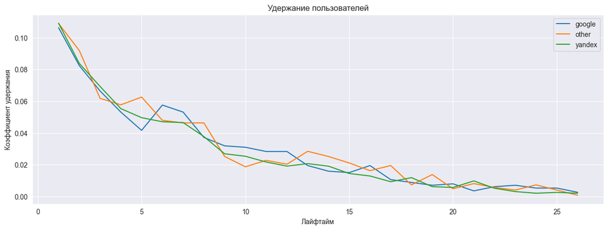

```python
# построим кривые удержания для сегментов
plot_retention(retention_source)
```

На графике можно заметить, что коэффициенты удержания в первый и последний лайфтаймы очень близки друг к другу.  
Коэффициенты удержания в первый лайфтайм: google - 10,63%, yandex - 10,91%.  
Коэффициенты удержания в последний лайфтайм: google - 0,27%, yandex - 0,21%.  
z-тест для долей подтвердил, что разница в коэффициентах удержания между google и yandex не является статистически значимой.

#### Сравнение коэффициентов конверсии

```python
# построим таблицу конверсии для сегментов
conversion_source = get_conversion(profiles, data, 'source')
conversion_source
```

| source | cohort_size | 0.0 | 1.0 | 2.0 | 3.0 | 4.0 | 5.0 | 6.0 | 7.0 | 8.0 | ... | 12.0 | 13.0 | 14.0 | 15.0 | 16.0 | 17.0 | 18.0 | 20.0 | 22.0 | 23.0 |
| --- | --- | --- | --- | --- | --- | --- | --- | --- | --- | --- | --- | --- | --- | --- | --- | --- | --- | --- | --- | --- | --- |
| google | 1129 | 0.199291 | 0.208149 | 0.213463 | 0.219663 | 0.223206 | 0.226749 | 0.232064 | 0.232950 | 0.233835 | ... | 0.241807 | 0.241807 | 0.241807 | 0.242693 | 0.242693 | 0.242693 | 0.242693 | 0.242693 | 0.242693 | 0.243578 |
| other | 1230 | 0.142276 | 0.152033 | 0.156098 | 0.157724 | 0.160976 | 0.163415 | 0.167480 | 0.169919 | 0.173984 | ... | 0.181301 | 0.182114 | 0.182114 | 0.183740 | 0.183740 | 0.184553 | 0.184553 | 0.184553 | 0.185366 | 0.185366 |
| yandex | 1934 | 0.201138 | 0.210962 | 0.217684 | 0.223888 | 0.230093 | 0.233195 | 0.234747 | 0.236815 | 0.237332 | ... | 0.240951 | 0.242503 | 0.243020 | 0.244571 | 0.245605 | 0.245605 | 0.246122 | 0.246639 | 0.247156 | 0.247156 |

3 rows × 23 columns

```python
# построим датафрейм для z-теста для долей
df_con = conversion_source[['cohort_size']].drop(index='other')
df_con['cr'] = df_con['cohort_size'] * conversion_source[23]
df_con['cr'] = df_con['cr'].astype('int')
df_con
```

| source | cohort_size | cr |
| --- | --- | --- |
| google | 1129 | 275 |
| yandex | 1934 | 478 |

Сформулируем гипотезы:  
H0: Коэффициенты конверсии в выборках по источникам google и yandex равны.  
H1: Коэффициенты конверсии в выборках по источникам google и yandex разные.

```python
# проверим гипотезу о конверсии
z_testing(df_con, 'cr')
```

```
p-значение: 0.82443
Не получилось отвергнуть нулевую гипотезу, нет оснований считать доли разными.
```

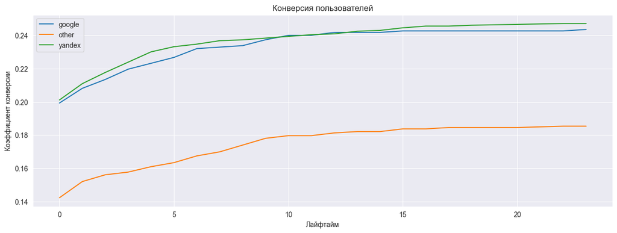

```python
# построим кривые конверсии для сегментов
plot_conversion(conversion_source)
```

На графике можно заметить, что коэффициенты конверсии очень близки друг к другу.  
Коэффициенты конверсии: google - 24,36%, yandex - 24,72%.  
z-тест для долей подтвердил, что разница в коэффициентах конверсии между google и yandex не является статистически значимой.

#### Сравнение средней продолжительности сессии

Сформулируем гипотезы:  
H0: Средняя продолжительность сессии в источниках google и yandex одинаковая.  
H1: Средняя продолжительность сессии в источниках google и yandex разная.

Проверим нормальность распределения данных для продолжительности сессии с помощью гистограмм и теста Шапиро-Уилка.

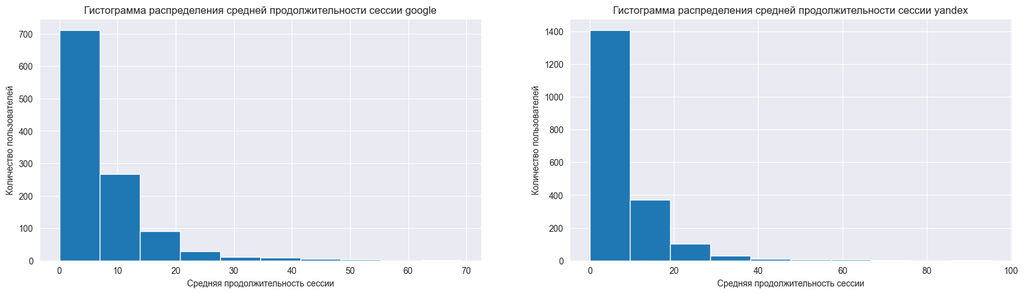

```python
ax = (
    profiles[profiles['source']=='google']['mean_duration']
    .plot(kind='hist', figsize=(20,5), ax=plt.subplot(1,2,1))
)
ax.set_xlabel('Средняя продолжительность сессии')
ax.set_ylabel('Количество пользователей')
ax.set_title('Гистограмма распределения средней продолжительности сессии google')
ax1 = (
    profiles[profiles['source']=='yandex']['mean_duration']
    .plot(kind='hist', figsize=(20,5), ax=plt.subplot(1,2,2))
)
ax1.set_xlabel('Средняя продолжительность сессии')
ax1.set_ylabel('Количество пользователей')
ax1.set_title('Гистограмма распределения средней продолжительности сессии yandex')
plt.show()
```

```python
print('google:', st.shapiro(profiles[profiles['source']=='google']['mean_duration']))
print('yandex:', st.shapiro(profiles[profiles['source']=='yandex']['mean_duration']))
```

```
google: ShapiroResult(statistic=0.7547410726547241, pvalue=6.247685279556497e-38)
yandex: ShapiroResult(statistic=0.734947681427002, pvalue=0.0)
```

Обе контрольные группы распределены ненормально. На гистограмме четко видно, что чем меньше средняя продолжительность сессии, тем больше пользователей в каждой из выборок. Из теста Шапиро-Уилка также следует вывод, что гипотезу о нормальности отклоняем (p-value < 0.0102 для каждой выборки).  
Таким образом, для проверки гипотезы о равенстве средних следует применять непараметрический тест Манна-Уитни.

```python
# построим функцию для теста Манна-Уитни
def mann_tester(measure, name):
    p_value = st.mannwhitneyu(profiles[profiles['source']=='google'][measure],
                        profiles[profiles['source']=='yandex'][measure])[1]

    print('p-значение:', round(p_value,5))
    if p_value < alpha_new:
        print('Отвергаем нулевую гипотезу: между средними есть значимая разница.')
    else:
        print('Не получилось отвергнуть нулевую гипотезу, нет оснований считать средние разными.')

    print(name, 'google:',
         round(profiles[profiles['source']=='google'][measure].mean(), 2))
    print(name, 'yandex:',
         round(profiles[profiles['source']=='yandex'][measure].mean(), 2))

    print('Относительная разница средней google к yandex:',
          '{0:.1f}%'.format((profiles[profiles['source']=='google'][measure].mean()
                             /profiles[profiles['source']=='yandex'][measure].mean()-1)*100))
```

```python
mann_tester('mean_duration', 'Средняя продолжительность сессии')
```

```
p-значение: 0.0189
Не получилось отвергнуть нулевую гипотезу, нет оснований считать средние разными.
Средняя продолжительность сессии google: 7.17
Средняя продолжительность сессии yandex: 7.86
Относительная разница средней google к yandex: -8.8%
```

Относительная разница в 8,8% между средними продолжительностями сессий google и yandex составляет лишь 0,69 минуты в абсолютных значениях.  
Тест Манна-Уитни также подтвердил отсутствие различий между двумя средними. Однако стоит отметить низкое значение p-value, например без поправки множественности результат был бы иным.  
Тем не менее разница все равно очень маленькая.

#### Сравнение средней частоты действий

Сформулируем гипотезы:  
H0: Средняя частота действий в источниках google и yandex одинаковая.  
H1: Средняя частота действий в источниках google и yandex разная.

Проверим нормальность распределения данных для продолжительности сессии с помощью гистограмм и теста Шапиро-Уилка.

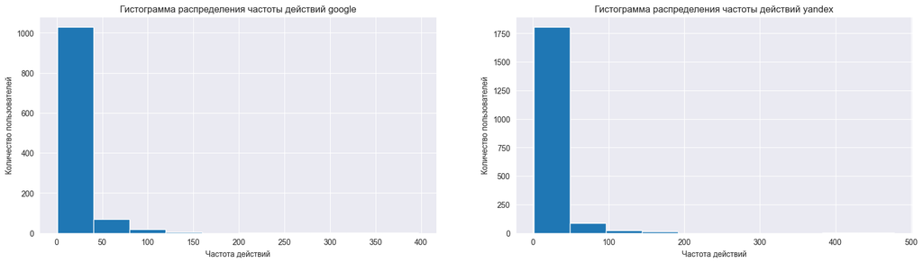

```python
ax = (
    profiles[profiles['source']=='google']['event_count']
    .plot(kind='hist', figsize=(20,5), ax=plt.subplot(1,2,1))
)
ax.set_xlabel('Частота действий')
ax.set_ylabel('Количество пользователей')
ax.set_title('Гистограмма распределения частоты действий google')
ax1 = (
    profiles[profiles['source']=='yandex']['event_count']
    .plot(kind='hist', figsize=(20,5), ax=plt.subplot(1,2,2))
)
ax1.set_xlabel('Частота действий')
ax1.set_ylabel('Количество пользователей')
ax1.set_title('Гистограмма распределения частоты действий yandex')
plt.show()
```

```python
print('google:', st.shapiro(profiles[profiles['source']=='google']['event_count']))
print('yandex:', st.shapiro(profiles[profiles['source']=='yandex']['event_count']))
```

```
google: ShapiroResult(statistic=0.40462565422058105, pvalue=0.0)
yandex: ShapiroResult(statistic=0.4191163182258606, pvalue=0.0)
```

Обе контрольные группы распределены ненормально. На гистограмме четко видно, что чем меньше частота действий, тем больше пользователей в каждой из выборок. Из теста Шапиро-Уилка также следует вывод, что гипотезу о нормальности отклоняем (p-value < 0.0102 для каждой выборки).  
Таким образом, для проверки гипотезы о равенстве средних следует применять непараметрический тест Манна-Уитни.

```python
mann_tester('event_count', 'Средняя частота действий')
```

```
p-значение: 0.57597
Не получилось отвергнуть нулевую гипотезу, нет оснований считать средние разными.
Средняя частота действий google: 18.11
Средняя частота действий yandex: 17.73
Относительная разница средней google к yandex: 2.1%
```

Относительная разница в 2,1% между средними частотами действий google и yandex составляет лишь 0,38 действия в абсолютных значениях.  
Тест Манна-Уитни также подтвердил отсутствие различий между двумя средними.

В заключение посмотрим, сколько пользователей пришло из каждого источника:

```python
source_count = profiles.groupby('source').agg({'user_id':'count'})
source_count['ratio, %'] = round(source_count['user_id']/len(profiles)*100,2)
source_count
```

| source | user_id | ratio, % |
| --- | --- | --- |
| google | 1129 | 26.30 |
| other | 1230 | 28.65 |
| yandex | 1934 | 45.05 |

Все 5 проверенных гипотез о равенстве коэффициентов и средних не получилось отвергнуть, то есть между источниками google и yandex нет статистически значимой разницы. Единственная гипотеза, которая показала близкий к уровню значимости p-value - это средняя продолжительность сессий. Однако даже при выборе пошагового метода поправки на множественную проверку гипотез это не изменило бы результат, так как данная гипотеза при ранжировании по возрастанию p-value была бы на первой позиции, то есть для нее уровень значимости бы не изменился.  
Из yandex пришло на 805 пользователей больше, что составляет 18,75% от общего количества пользователей.  
Таким образом, yandex является более популярным источником, но значимой разницы в показателях между yandex и google нет.

### Выводы и рекомендации

Предобработка данных показала, что данные идеальны: в них нет пропусков и дубликатов. Пришлось лишь исправить несколько маленьких неточностей: заменить названия столбцов, привести названия событий к единому виду и привести тип данных к дате и времени.

В ходе исследовательского анализа был выявлен следующий ряд особенностей:

- Удержание пользователей у мобильного приложения довольно низкое с самого начала;
- Из всех пользователей в целом лишь 11% возвращаются на следующий день после своего первого события, через неделю - 5%, через 2 недели - 2%, через 3 недели - 1%;
- Медианная продолжительность сесси 2,45 минут, а средняя - 5,8. Это нормальный результат;
- Медианная и средняя продолжительность сессии были чуть выше в первую неделю, далее средняя колебалась в диапазоне от 5 до 7 минут, а медианная - от 1,5 до 3 минут. В конце наметился небольшой рост;
- У 60% пользователей длительность сессии составляет менее 7 минут, у 25% - от 7 до 14 минут. Это также нормальный результат;
- Среднее число сессий на пользователя за весь период составило 3,3 сессии. Число сессий на пользователя в день колеблется от 1,65 до 2,05 сессий. Это очень хороший результат;
- Среднее число действий на пользователя за весь период равно 17,3;
- Частота действий пользователя в день колеблется от 7,7 до 12,5, это хороший показатель активности зашедших в приложение пользователей;
- Среднее количество уникальных пользователей в день равно 279,18;
- Среднее количество уникальных пользователей в неделю равно 1382,5;
- День недели с самой высокой активностью - понедельник (11 600 действий и 11 действий на пользователя);
- В течение недели наблюдается ярко выраженная цикличность: количество действий в целом сильно растет в воскресенье и в понедельник, далее, достигнув пика, со вторника начинает падать вплоть до субботы, после чего, достигнув дна, снова начинает бурный рост.
- В первую неделю абсолютное количество действий ниже, при этом максимум частоты действий пользователя (более 12 действий) в день был достигнут в первые два дня. Количество уникальных пользователей в день в первую неделю ниже среднего и последующих недель (во все дни в диапазоне от 175 до 225). Это говорит о более высокой активности пользователей в начале периода;
- Конверсия в целевое действие составила 22,85% от всех пользователей, что является хорошим показателем;
- 80,43% от всех пользователей, просмотревших контакты, сделали это в первый день своего посещения;
- По сравнению с другими вариантами больше всего пользователей совершили 2 различных события (31,8%);
- Среди просматривавших контакты по сравнению с другими вариантами больше всего пользователей совершили 3 различных события (35,78%);
- Пользовательский путь до целевого действия не является однородным и какая-либо общая воронка событий отсутствует;
- Воронки из 4 событий показывают конверию не более 4%;
- Лучшей воронкой из 3 событий является воронка search_1-->photos_show-->contacts_show, конверсия в просмотры контактов составила 24%. Однако в эту воронку попали лишь 20% от всех просматривавших контакты пользователей.

При сегментации по частоте действий сегменты показали себя следующим образом:

| Частота действий | Удержание в 1-й день | Конверсия |
| --- | --- | --- |
| Очень высокая | 24% | 36% |
| Высокая | 9% | 24% |
| Средняя | 7% | 18% |
| Низкая | 4% | 15% |

Проверка статистических гипотез показала, что между yandex и google нет какой-либо значимой разницы по коэффициентам удержания и конверсии, средней продолжительности сессии, частоте действий. Тем не менее yandex является более популярным источником: из него пришло на 805 пользователей больше, чем из google, что составляет 18,75% от всех пользователей.

Рекомендации:

- Сегментация пользователей показала: чем выше частота действий, тем выше конверсия и удержание. Таким образом, необходимо более тщательно рассмотреть поведение пользователей с очень высокой частотой и сравнить его с другими сегментами. Возможно, дело в том, что пользователи с меньшей частотой действий начинают не с тех событий, что пользователи с более высокой частотой.
- Необходимо улучшить формирование данных о пользовательских сессиях: добавить в обработку данных флаги 'начало сессии' и 'конец сессии', что позволит точно фиксировать продолжительность и количество сессий. Или принять стандартную продолжительность сессии за определенный промежуток времени, например 5 минут. Но тогда в данных могут быть неточности.